# Capstone Project — AIML

## Account-Level Churn Prediction for an E-Commerce / DTH Operator

*Milestone 1 · Strategic framing, data diagnostic and exploratory findings*

# 1 — Strategic framing

## 1.1 Why this project exists

The operator competes in a saturated, low-switching-cost market where the economics of growth are dictated by **retention**, not acquisition. In this business the revenue-bearing unit is an *account* that typically aggregates several end customers — so each account lost removes recurring revenue today and the option value of cross-sell tomorrow.

Three forces turn churn into a board-level concern:

1. **CAC is rising faster than LTV.** Every percentage point of churn avoided is worth more than the equivalent point added through acquisition.
2. **Revenue Assurance rejects blanket discounts.** Retention spend must be defended on a *per-account expected value* basis, not on aggregate campaign volume.
3. **Behavioural leakage is invisible in traditional reporting.** Churn builds up silently across service complaints, payment friction and engagement decay long before it hits the revenue line.

## 1.2 What this milestone delivers

- A framed, defensible problem statement the downstream model will solve.
- A cleaned, audited dataset the company can trust as the single source of truth for churn modelling.
- An exploratory view that already answers *"who churns and why"* in business terms.
- A methodological blueprint for the modelling phase — optimised for recall on churners and for offers that survive Revenue Assurance review.

## 1.3 What success looks like after Milestone 2

A scored list of at-risk accounts ranked by **expected revenue loss**, paired with **segmented retention plays** whose unit economics are explicit and defensible.

## 1.4 Dataset dictionary (as provided)

| Field | Business meaning |
| --- | --- |
| `AccountID` | Unique account key (not predictive). |
| `Churn` | **Target.** 1 = account churned, 0 = retained. |
| `Tenure` | Months the account has been active. |
| `City_Tier` | Tier of the primary customer's city (1 = metro, 3 = smaller city). |
| `CC_Contacted_LY` | Customer-care contacts initiated by the account's users in the last 12 months. |
| `Payment` | Preferred payment method. |
| `Gender` | Primary customer gender. |
| `Service_Score` | Satisfaction rating on the service itself. |
| `Account_user_count` | End customers tagged to the account. |
| `account_segment` | Commercial segment based on spend. |
| `CC_Agent_Score` | Satisfaction rating on the CC agent experience. |
| `Marital_Status` | Primary customer marital status. |
| `rev_per_month` | Monthly revenue generated by the account (trailing 12m). |
| `Complain_ly` | At least one complaint in the last 12 months (0/1). |
| `rev_growth_yoy` | Revenue growth (last 12m vs prior 12m), %. |
| `coupon_used_for_payment` | Coupon redemptions in the last 12 months. |
| `Day_Since_CC_connect` | Days since the last customer-care contact. |
| `cashback` | Monthly average cashback earned. |
| `Login_device` | Preferred login device. |

# 2 — Analytical environment

All work in this notebook is deterministic (fixed seed), warning-free, and uses a single palette and figure size for visual consistency. Helpers are defined upfront so that data cleaning, diagnostics and plotting are expressed as thin pipelines rather than ad-hoc scripts.

```python
%pip install openpyxl
```

```python
from __future__ import annotations

# Core stack
import numpy as np
import pandas as pd

# Visualisation
import matplotlib.pyplot as plt
import matplotlib.ticker as mtick
import seaborn as sns

# ML utilities used only for imputation diagnostics in this milestone
from sklearn.impute import KNNImputer

# Hygiene
import warnings
warnings.filterwarnings("ignore")

# ------------------------------------------------------------------
# Global config
# ------------------------------------------------------------------
SEED = 7
np.random.seed(SEED)

PALETTE = {
    "primary":   "#1F4E79",   # corporate blue
    "accent":    "#ED7D31",   # amber
    "muted":     "#7F7F7F",   # grey
    "positive":  "#2E7D32",   # green (retained)
    "negative":  "#C0392B",   # red   (churn)
}
BINARY_CMAP = [PALETTE["positive"], PALETTE["negative"]]

sns.set_theme(style="whitegrid", context="talk")
plt.rcParams.update({
    "figure.figsize":   (10, 5),
    "axes.titlesize":   13,
    "axes.titleweight": "bold",
    "axes.labelsize":   11,
    "axes.spines.top":     False,
    "axes.spines.right":   False,
})
pd.set_option("display.max_columns",   None)
pd.set_option("display.float_format",  "{:,.3f}".format)
```

## 2.1 Reusable helpers

These small functions keep the notebook compact and self-documenting. They will be reused throughout the exploratory and preprocessing phases.

```python
def profile_columns(frame: pd.DataFrame) -> pd.DataFrame:
    """One-row-per-column diagnostic: dtype, non-null, unique, missing %."""
    return pd.DataFrame({
        "dtype":        frame.dtypes.astype(str),
        "n_non_null":   frame.notna().sum(),
        "n_unique":     frame.nunique(dropna=True),
        "missing_pct":  (frame.isna().mean() * 100).round(2),
    }).sort_values("missing_pct", ascending=False)


def churn_rate_by(frame: pd.DataFrame, column: str, target: str = "Churn") -> pd.Series:
    """Churn rate (%) per category of `column`, ordered descending."""
    return (frame.groupby(column)[target].mean() * 100).round(2).sort_values(ascending=False)


def winsorize_pct(series: pd.Series, lower: float = 0.01, upper: float = 0.99) -> pd.Series:
    """Percentile-based capping. Preserves order, neutralises extremes."""
    lo, hi = series.quantile([lower, upper])
    return series.clip(lower=lo, upper=hi)


def bar_rate(rate: pd.Series, title: str, xlabel: str = "Churn rate (%)") -> None:
    """Horizontal bar plot for a churn-rate Series."""
    fig, ax = plt.subplots(figsize=(8, max(3, 0.55 * len(rate))))
    sns.barplot(x=rate.values, y=rate.index.astype(str),
                color=PALETTE["primary"], ax=ax)
    ax.set_title(title)
    ax.set_xlabel(xlabel); ax.set_ylabel("")
    ax.xaxis.set_major_formatter(mtick.FormatStrFormatter("%.0f"))
    for i, v in enumerate(rate.values):
        ax.text(v + 0.3, i, f"{v:.1f}", va="center", fontsize=10,
                color=PALETTE["muted"])
    plt.tight_layout(); plt.show()
```

# 3 — Data ingestion and initial landscape

```python
SOURCE_FILE  = "Customer_Churn_Data.xlsx"
SOURCE_SHEET = "Data for DSBA"

raw = pd.read_excel(SOURCE_FILE, sheet_name=SOURCE_SHEET)
df  = raw.copy()
df.head()
```

|  | AccountID | Churn | Tenure | City_Tier | CC_Contacted_LY | Payment | Gender | Service_Score | Account_user_count | account_segment | CC_Agent_Score | Marital_Status | rev_per_month | Complain_ly | rev_growth_yoy | coupon_used_for_payment | Day_Since_CC_connect | cashback | Login_device |
| --- | --- | --- | --- | --- | --- | --- | --- | --- | --- | --- | --- | --- | --- | --- | --- | --- | --- | --- | --- |
| 0 | 20000 | 1 | 4 | 3.000 | 6.000 | Debit Card | Female | 3.000 | 3 | Super | 2.000 | Single | 9 | 1.000 | 11 | 1 | 5 | 159.930 | Mobile |
| 1 | 20001 | 1 | 0 | 1.000 | 8.000 | UPI | Male | 3.000 | 4 | Regular Plus | 3.000 | Single | 7 | 1.000 | 15 | 0 | 0 | 120.900 | Mobile |
| 2 | 20002 | 1 | 0 | 1.000 | 30.000 | Debit Card | Male | 2.000 | 4 | Regular Plus | 3.000 | Single | 6 | 1.000 | 14 | 0 | 3 | NaN | Mobile |
| 3 | 20003 | 1 | 0 | 3.000 | 15.000 | Debit Card | Male | 2.000 | 4 | Super | 5.000 | Single | 8 | 0.000 | 23 | 0 | 3 | 134.070 | Mobile |
| 4 | 20004 | 1 | 0 | 1.000 | 12.000 | Credit Card | Male | 2.000 | 3 | Regular Plus | 5.000 | Single | 3 | 0.000 | 11 | 1 | 3 | 129.600 | Mobile |

```python
n_rows, n_cols = df.shape
print(f"Accounts (rows): {n_rows:,}")
print(f"Variables (cols): {n_cols}")
print(f"Unique AccountID: {df['AccountID'].nunique():,}  (should equal rows)")
print(f"Duplicated rows: {df.duplicated().sum()}")
```

```
Accounts (rows): 11,260
Variables (cols): 19
Unique AccountID: 11,260  (should equal rows)
Duplicated rows: 0
```

**Landscape at a glance**

11,260 accounts, 19 variables, no duplicates, no identifier collisions. The granularity of the table is *one row per account*. `AccountID` is a pure key and will be removed before modelling — it carries no behavioural signal and would only inflate dimensionality.

# 4 — Data overview and quality diagnostic

```python
profile_columns(df)
```

|  | dtype | n_non_null | n_unique | missing_pct |
| --- | --- | --- | --- | --- |
| cashback | object | 10789 | 5693 | 4.180 |
| Day_Since_CC_connect | object | 10903 | 24 | 3.170 |
| Complain_ly | float64 | 10903 | 2 | 3.170 |
| Login_device | object | 11039 | 3 | 1.960 |
| Marital_Status | object | 11048 | 3 | 1.880 |
| CC_Agent_Score | float64 | 11144 | 5 | 1.030 |
| City_Tier | float64 | 11148 | 3 | 0.990 |
| Account_user_count | object | 11148 | 7 | 0.990 |
| Payment | object | 11151 | 5 | 0.970 |
| Gender | object | 11152 | 4 | 0.960 |
| Tenure | object | 11158 | 38 | 0.910 |
| CC_Contacted_LY | float64 | 11158 | 44 | 0.910 |
| rev_per_month | object | 11158 | 59 | 0.910 |
| Service_Score | float64 | 11162 | 6 | 0.870 |
| account_segment | object | 11163 | 7 | 0.860 |
| coupon_used_for_payment | object | 11260 | 20 | 0.000 |
| rev_growth_yoy | object | 11260 | 20 | 0.000 |
| Churn | int64 | 11260 | 2 | 0.000 |
| AccountID | int64 | 11260 | 11260 | 0.000 |

**Quality diagnostic — first pass**

Seven variables that *should* be numeric are stored as `object`: `Tenure`, `Account_user_count`, `rev_per_month`, `rev_growth_yoy`, `coupon_used_for_payment`, `Day_Since_CC_connect`, `cashback`. This is a reliable fingerprint of **placeholder tokens** injected during data entry or ETL (a single non-numeric cell forces the whole column to `object`).

Several columns also show small-but-non-trivial missing fractions (all well below 5%), mostly on behavioural metrics.

Before touching distributions or correlations, we must **land every column on its correct type** and **harmonise every categorical label**. Anything else risks silently corrupting the rest of the analysis.

```python
# Explicit inventory of non-numeric tokens in pseudo-numeric columns
pseudo_numeric = ["Tenure", "Account_user_count", "rev_per_month", "rev_growth_yoy",
                  "coupon_used_for_payment", "Day_Since_CC_connect", "cashback"]

tokens_found = {
    c: sorted({v for v in df[c].unique()
               if isinstance(v, str) and not v.replace(".", "", 1).lstrip("-").isdigit()})
    for c in pseudo_numeric
}
pd.Series(tokens_found, name="placeholders")
```

```
Tenure                           [#]
Account_user_count               [@]
rev_per_month                    [+]
rev_growth_yoy                   [$]
coupon_used_for_payment    [#, $, *]
Day_Since_CC_connect             [$]
cashback                         [$]
Name: placeholders, dtype: object
```

```python
# Explicit inventory of categorical labels
for col in ["Payment", "Gender", "account_segment", "Marital_Status", "Login_device"]:
    print(f"— {col}")
    print(df[col].value_counts(dropna=False).to_string())
    print()
```

```
— Payment
Payment
Debit Card          4587
Credit Card         3511
E wallet            1217
Cash on Delivery    1014
UPI                  822
NaN                  109

— Gender
Gender
Male      6328
Female    4178
M          376
F          270
NaN        108

— account_segment
account_segment
Super           4062
Regular Plus    3862
HNI             1639
Super Plus       771
Regular          520
Regular +        262
NaN               97
Super +           47

— Marital_Status
Marital_Status
Married     5860
Single      3520
Divorced    1668
NaN          212

— Login_device
Login_device
Mobile      7482
Computer    3018
&&&&         539
NaN          221
```

**Findings of the quality diagnostic**

[output not shown]

All treatment is applied in a single, idempotent pipeline so it can be re-run on new data batches without side effects.

# 5 — Cleaning pipeline

The cleaning logic is expressed as a chain of small, auditable steps. Each step has a single responsibility and the whole pipeline is deterministic.

```python
GENDER_MAP  = {"M": "Male", "F": "Female"}
SEGMENT_MAP = {"Regular +": "Regular Plus", "Super +": "Super Plus"}
DEVICE_BAD  = ["&&&&"]

def drop_identifier(frame: pd.DataFrame) -> pd.DataFrame:
    return frame.drop(columns=[c for c in ["AccountID"] if c in frame.columns])

def coerce_numeric(frame: pd.DataFrame, cols: list[str]) -> pd.DataFrame:
    out = frame.copy()
    for c in cols:
        out[c] = pd.to_numeric(out[c], errors="coerce")
    return out

def canonicalise_categoricals(frame: pd.DataFrame) -> pd.DataFrame:
    return frame.assign(
        Gender          = frame["Gender"].replace(GENDER_MAP),
        account_segment = frame["account_segment"].replace(SEGMENT_MAP),
        Login_device    = frame["Login_device"].replace({t: np.nan for t in DEVICE_BAD}),
    )

df = (raw
      .pipe(drop_identifier)
      .pipe(coerce_numeric, pseudo_numeric)
      .pipe(canonicalise_categoricals))

# Quick post-cleaning profile
profile_columns(df).head(10)
```

|  | dtype | n_non_null | n_unique | missing_pct |
| --- | --- | --- | --- | --- |
| rev_per_month | float64 | 10469 | 58 | 7.020 |
| Login_device | object | 10500 | 2 | 6.750 |
| cashback | float64 | 10787 | 5692 | 4.200 |
| Account_user_count | float64 | 10816 | 6 | 3.940 |
| Day_Since_CC_connect | float64 | 10902 | 23 | 3.180 |
| Complain_ly | float64 | 10903 | 2 | 3.170 |
| Tenure | float64 | 11042 | 37 | 1.940 |
| Marital_Status | object | 11048 | 3 | 1.880 |
| CC_Agent_Score | float64 | 11144 | 5 | 1.030 |
| City_Tier | float64 | 11148 | 3 | 0.990 |

Every pseudo-numeric column now carries a proper `float64` dtype. Categorical labels have been unified. Missing counts have grown on the coerced columns — this is the expected, honest picture: what used to be hidden placeholders is now explicitly `NaN`, ready for imputation.

# 6 — Missing value strategy

- **Numeric:** `KNNImputer` (k = 5) on the continuous block. KNN respects the joint distribution of the features, which is preferable to univariate median imputation when we want to preserve relationships between behavioural variables (revenue, cashback, coupons, CC contacts).
- **Categorical:** Mode imputation — low missing fractions, high concentration on the dominant category, minimal distortion.

For the modelling phase this logic will move inside a `ColumnTransformer` fit on the training fold only. At this exploratory stage we apply it to the full dataset for readability.

```python
numeric_cols     = [c for c in df.select_dtypes(include=[np.number]).columns if c != "Churn"]
categorical_cols = df.select_dtypes(include=["object"]).columns.tolist()

# Categorical — mode
for c in categorical_cols:
    df[c] = df[c].fillna(df[c].mode().iloc[0])

# Numeric — KNN (k=5)
knn = KNNImputer(n_neighbors=5, weights="distance")
df[numeric_cols] = knn.fit_transform(df[numeric_cols])

# Ordinal-like columns (originally integer-valued) must be rounded back
# to preserve their categorical nature after KNN imputation.
ordinal_like = ["City_Tier", "Service_Score", "CC_Agent_Score",
                "Complain_ly", "Account_user_count"]
for c in ordinal_like:
    df[c] = df[c].round().astype(int)

# Sanity
assert df.isna().sum().sum() == 0
df.isna().sum().sum()
```

```
np.int64(0)
```

The dataset is now fully populated. No `NaN` remains anywhere.

```python
df.describe().T
```

|  | count | mean | std | min | 25% | 50% | 75% | max |
| --- | --- | --- | --- | --- | --- | --- | --- | --- |
| Churn | 11,260.000 | 0.168 | 0.374 | 0.000 | 0.000 | 0.000 | 0.000 | 1.000 |
| Tenure | 11,260.000 | 10.989 | 12.785 | 0.000 | 2.000 | 9.000 | 16.000 | 99.000 |
| City_Tier | 11,260.000 | 1.654 | 0.913 | 1.000 | 1.000 | 1.000 | 3.000 | 3.000 |
| CC_Contacted_LY | 11,260.000 | 17.859 | 8.829 | 4.000 | 11.000 | 16.000 | 23.000 | 132.000 |
| Service_Score | 11,260.000 | 2.903 | 0.724 | 0.000 | 2.000 | 3.000 | 3.000 | 5.000 |
| Account_user_count | 11,260.000 | 3.690 | 1.013 | 1.000 | 3.000 | 4.000 | 4.000 | 6.000 |
| CC_Agent_Score | 11,260.000 | 3.066 | 1.376 | 1.000 | 2.000 | 3.000 | 4.000 | 5.000 |
| rev_per_month | 11,260.000 | 6.339 | 11.609 | 1.000 | 3.000 | 5.000 | 7.000 | 140.000 |
| Complain_ly | 11,260.000 | 0.283 | 0.451 | 0.000 | 0.000 | 0.000 | 1.000 | 1.000 |
| rev_growth_yoy | 11,260.000 | 16.193 | 3.757 | 4.000 | 13.000 | 15.000 | 19.000 | 28.000 |
| coupon_used_for_payment | 11,260.000 | 1.791 | 1.969 | 0.000 | 1.000 | 1.000 | 2.000 | 16.000 |
| Day_Since_CC_connect | 11,260.000 | 4.624 | 3.663 | 0.000 | 2.000 | 3.000 | 7.705 | 47.000 |
| cashback | 11,260.000 | 196.198 | 176.389 | 0.000 | 147.358 | 165.395 | 200.100 | 1,997.000 |

**Descriptive statistics — what stands out**

# 7 — Target profile

```
Churn
Retained   83.160
Churned    16.840
```

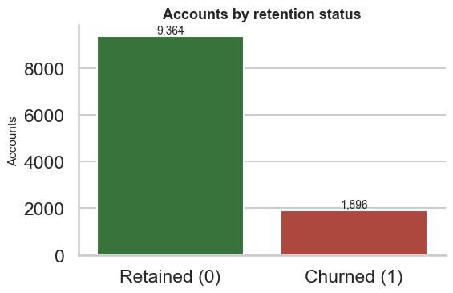

```python
target_share = (df["Churn"].value_counts(normalize=True) * 100).round(2)
print(target_share.rename({0: "Retained", 1: "Churned"}).to_string())

fig, ax = plt.subplots(figsize=(6, 4))
sns.countplot(x="Churn", data=df, palette=BINARY_CMAP, ax=ax)
for p in ax.patches:
    ax.annotate(f"{int(p.get_height()):,}",
                (p.get_x() + p.get_width() / 2, p.get_height()),
                ha="center", va="bottom", fontsize=10)
ax.set_xticklabels(["Retained (0)", "Churned (1)"])
ax.set_title("Accounts by retention status")
ax.set_xlabel(""); ax.set_ylabel("Accounts")
plt.tight_layout(); plt.show()
```

**Class imbalance is moderate and consequential**

The retained class dominates at ~83%. A naïve "predict retained" classifier would already score ~83% accuracy while delivering **zero** business value — it would miss exactly the accounts this project exists to save.

The downstream model will therefore:

1. Optimise for **Recall on the churn class** (the business cost of a missed churner is higher than a false alarm).
2. Report **F1** and **PR-AUC** as supporting metrics.
3. Translate model quality into **top-decile capture rate** and **revenue-at-risk saved** so Revenue Assurance can evaluate the campaigns on their own terms.

# 8 — Exploratory findings (Univariate, Bivariate and Multivariate)

The exploratory analysis is organised in three explicit layers, in line with the audit checklist:

- **Univariate analysis** — distribution and shape of each individual variable (§8.1 left panels, §8.5 single-variable rates, §8.6 single-variable distributions, §7 target profile).
- **Bivariate analysis** — every predictor against the target `Churn` (§8.1 right panel onwards, §8.2 through §8.6 churn-rate-by tables, §8.7 correlation with the target).
- **Multivariate analysis** — interactions between three or more variables, including the correlation matrix (§8.7) and the high-risk archetype that combines six predictors (§8.8).

The substantive findings are organised around the drivers the retention team can act on: **tenure, complaints, commercial segment, payment mode, customer profile, device, and engagement decay**. Each subsection presents the chart, the numerical breakdown and the business reading.

## 8.1 Tenure — the dominant protective factor

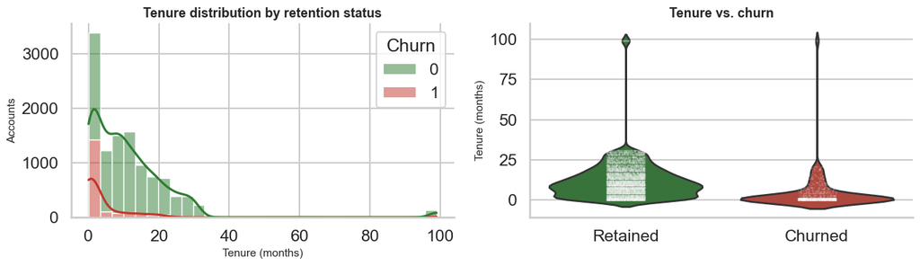

| Churn | mean | median | std |
| --- | --- | --- | --- |
| 0 | 12.330 | 10.000 | 12.530 |
| 1 | 4.380 | 1.000 | 11.950 |

```python
fig, axes = plt.subplots(1, 2, figsize=(13, 4))

# Left — distribution, coloured by churn
sns.histplot(data=df, x="Tenure", hue="Churn", bins=30, kde=True,
             palette=BINARY_CMAP, ax=axes[0], multiple="stack")
axes[0].set_title("Tenure distribution by retention status")
axes[0].set_xlabel("Tenure (months)"); axes[0].set_ylabel("Accounts")

# Right — violin + strip
sns.violinplot(x="Churn", y="Tenure", data=df,
               palette=BINARY_CMAP, inner=None, ax=axes[1])
sns.stripplot(x="Churn", y="Tenure", data=df,
              color="white", alpha=0.15, size=1.5, ax=axes[1])
axes[1].set_title("Tenure vs. churn")
axes[1].set_xticklabels(["Retained", "Churned"])
axes[1].set_xlabel(""); axes[1].set_ylabel("Tenure (months)")
plt.tight_layout(); plt.show()

df.groupby("Churn")["Tenure"].agg(["mean", "median", "std"]).round(2)
```

The churn class concentrates in the **early months of the account life-cycle**. Retained accounts span the full tenure range, while churners cluster at the low end. This is the single most important insight of the milestone: **retention effort pays back most when applied to the first months after account creation**.

## 8.2 Complaints — an operational early-warning signal

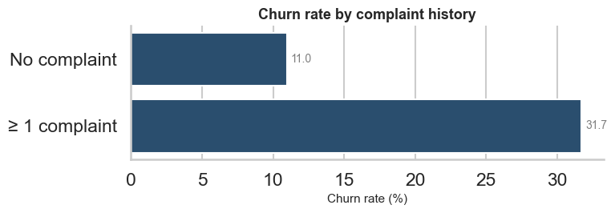

```
No complaint    10.960
≥ 1 complaint   31.700
Name: Churn, dtype: float64
```

```python
complain_rate = (df.groupby("Complain_ly")["Churn"].mean() * 100).round(2)
complain_rate.index = ["No complaint", "≥ 1 complaint"]
bar_rate(complain_rate, "Churn rate by complaint history")
complain_rate
```

## 8.3 Commercial segment and geography

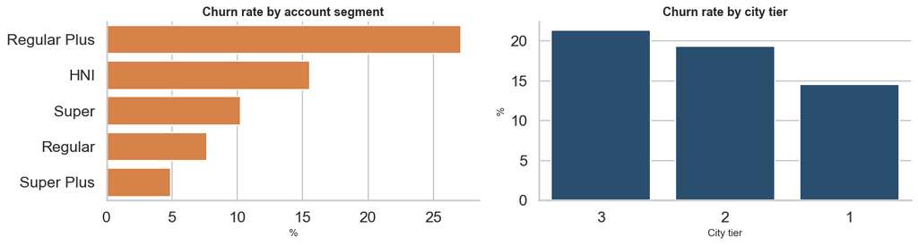

|  | segment_churn_% | tier_churn_% |
| --- | --- | --- |
| Regular Plus | 27.130 | NaN |
| HNI | 15.560 | NaN |
| Super | 10.240 | NaN |
| Regular | 7.690 | NaN |
| Super Plus | 4.890 | NaN |
| 3 | NaN | 21.370 |
| 2 | NaN | 19.390 |
| 1 | NaN | 14.540 |

```python
seg_rate  = churn_rate_by(df, "account_segment")
tier_rate = churn_rate_by(df, "City_Tier")

fig, axes = plt.subplots(1, 2, figsize=(14, 4))
sns.barplot(x=seg_rate.values, y=seg_rate.index,
            color=PALETTE["accent"], ax=axes[0])
axes[0].set_title("Churn rate by account segment"); axes[0].set_xlabel("%")
axes[0].set_ylabel("")

sns.barplot(x=tier_rate.index.astype(str), y=tier_rate.values,
            color=PALETTE["primary"], ax=axes[1])
axes[1].set_title("Churn rate by city tier")
axes[1].set_xlabel("City tier"); axes[1].set_ylabel("%")
plt.tight_layout(); plt.show()

pd.concat([seg_rate.rename("segment_churn_%"), tier_rate.rename("tier_churn_%")], axis=1)
```

**Regular Plus** is the single largest churn pocket (~27% churn rate) and should anchor the campaign roadmap. **HNI** accounts churn at a moderate rate but deserve disproportionate attention because each lost HNI account is materially more expensive than multiple Regular losses — the correct metric here is *expected revenue lost*, not *count of accounts lost*. Tier-3 cities carry the highest geographical risk.

## 8.4 Payment method — a proxy for platform commitment

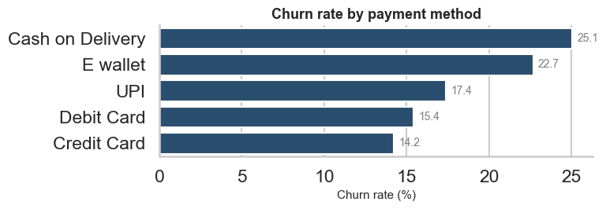

```
Payment
Cash on Delivery   25.050
E wallet           22.680
UPI                17.400
Debit Card         15.420
Credit Card        14.210
Name: Churn, dtype: float64
```

```python
pay_rate = churn_rate_by(df, "Payment")
bar_rate(pay_rate, "Churn rate by payment method")
pay_rate
```

**Cash-on-Delivery** (25.1%) and **E-wallet** (22.7%) payers churn meaningfully more than card payers (~14–15%). This is an *implicit loyalty signal*: customers with a stored card on file have a frictional stake in the platform, while cash and e-wallet users can leave without any administrative cost. Migrating high-value accounts toward card-on-file should be treated as a retention lever in its own right.

## 8.5 Customer profile — marital status, gender, device

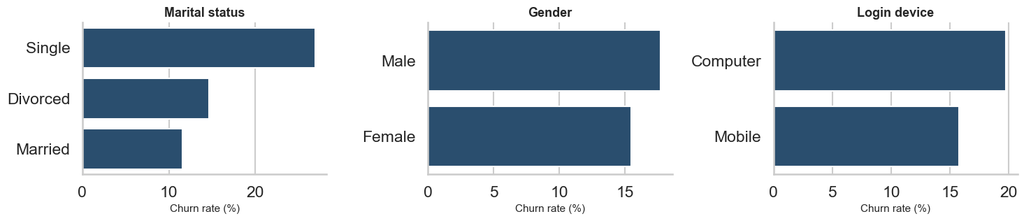

|  | marital | gender | device |
| --- | --- | --- | --- |
| Single | 26.900 | NaN | NaN |
| Divorced | 14.630 | NaN | NaN |
| Married | 11.610 | NaN | NaN |
| Male | NaN | 17.720 | NaN |
| Female | NaN | 15.490 | NaN |
| Computer | NaN | NaN | 19.780 |
| Mobile | NaN | NaN | 15.760 |

```python
marital_rate = churn_rate_by(df, "Marital_Status")
gender_rate  = churn_rate_by(df, "Gender")
device_rate  = churn_rate_by(df, "Login_device")

fig, axes = plt.subplots(1, 3, figsize=(15, 3.5))
for ax, rate, title in zip(
    axes, [marital_rate, gender_rate, device_rate],
    ["Marital status", "Gender", "Login device"]):
    sns.barplot(x=rate.values, y=rate.index.astype(str),
                color=PALETTE["primary"], ax=ax)
    ax.set_title(title); ax.set_xlabel("Churn rate (%)"); ax.set_ylabel("")
plt.tight_layout(); plt.show()

pd.concat([marital_rate.rename("marital"), gender_rate.rename("gender"),
           device_rate.rename("device")], axis=1)
```

- **Marital status** is a strong behavioural correlate: Single customers churn at **26.9%** versus **11.6%** for Married customers. Household inertia is a genuine retention force.
- **Gender** effects are small (<3 pts) and unlikely to justify a dedicated campaign track.
- **Login device** shows a *counter-intuitive* pattern: **Computer-first** users churn at **19.8%**, above Mobile-first users at **15.8%**. The probable mechanic is that mobile users are effectively locked in by push notifications, cashback prompts and stored payment methods, while desktop-heavy users face zero friction to switch tabs to a competitor. Mobile engagement should therefore be treated as a **retention asset** and desktop-only accounts should be actively nudged toward the app.

## 8.6 Engagement decay — the composite signal

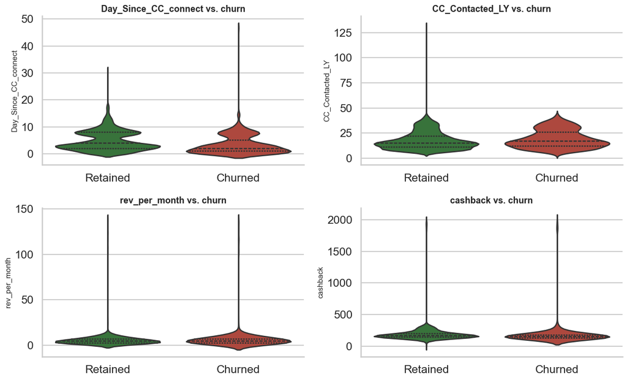

```python
fig, axes = plt.subplots(2, 2, figsize=(13, 8))
for ax, col in zip(axes.ravel(),
                   ["Day_Since_CC_connect", "CC_Contacted_LY",
                    "rev_per_month", "cashback"]):
    sns.violinplot(x="Churn", y=col, data=df,
                   palette=BINARY_CMAP, inner="quartile", ax=ax)
    ax.set_title(f"{col} vs. churn")
    ax.set_xticklabels(["Retained", "Churned"])
    ax.set_xlabel("")
plt.tight_layout(); plt.show()
```

## 8.7 Correlation structure

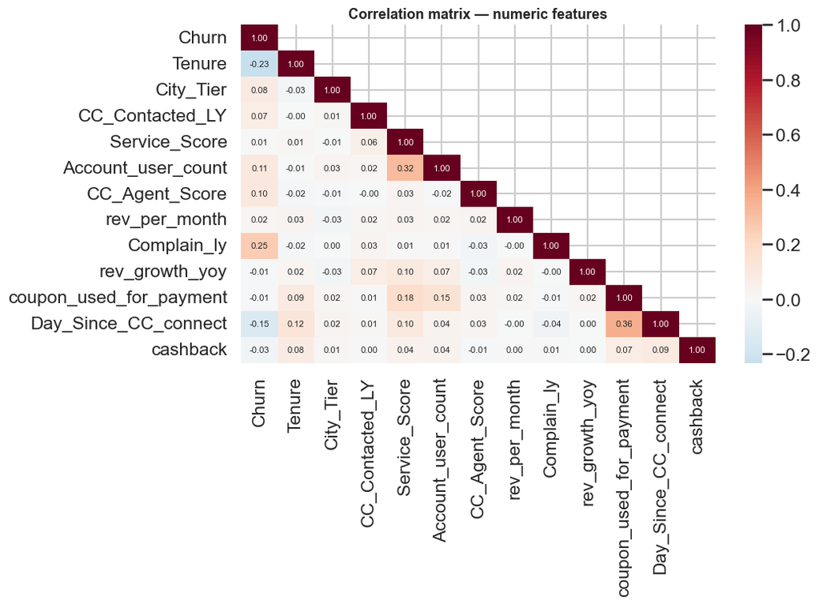

```
Tenure                    -0.233
Day_Since_CC_connect      -0.147
cashback                  -0.032
coupon_used_for_payment   -0.015
rev_growth_yoy            -0.014
Service_Score              0.008
rev_per_month              0.022
CC_Contacted_LY            0.072
City_Tier                  0.084
CC_Agent_Score             0.105
Account_user_count         0.107
Complain_ly                0.250
Churn                      1.000
Name: Churn, dtype: float64
```

```python
numeric_df = df.select_dtypes(include=[np.number])
corr = numeric_df.corr()

fig, ax = plt.subplots(figsize=(11, 8))
mask = np.triu(np.ones_like(corr, dtype=bool), k=1)
sns.heatmap(corr, mask=mask, cmap="RdBu_r", center=0,
            annot=True, fmt=".2f", annot_kws={"size": 8}, ax=ax)
ax.set_title("Correlation matrix — numeric features")
plt.tight_layout(); plt.show()

corr["Churn"].sort_values().round(3)
```

**Correlation takeaways**

- The variables most (linearly) correlated with `Churn` are `Tenure` (negative, -0.23), `Complain_ly` (positive, +0.25), `Day_Since_CC_connect` (negative, -0.14), `CC_Agent_Score` (positive, +0.10), and `Account_user_count` (positive, +0.10).
- No pair of predictors is correlated above ~0.6 in absolute value — **no multicollinearity threat** for a linear baseline.
- The predictive payload is distributed across many features at modest magnitudes; this confirms that a **non-linear, tree-based ensemble** is the natural primary candidate for Milestone 2.

## 8.8 Multivariate analysis — the high-risk archetype

The bivariate views (§8.1–§8.6) each isolate a single predictor against `Churn`. The correlation matrix (§8.7) extends this to pairwise relationships among numeric variables. Neither view captures the actual structure of risk on this dataset, which is **multivariate by construction**: an account is at risk because *several* signals stack up at the same time, not because any single one fires in isolation.

The table below cross-references the six strongest bivariate signals identified earlier and isolates the *intersection* — accounts that match every one of them simultaneously.

[output not shown]

**The multivariate reading.** When *three or more* of these traits co-occur on the same account, the conditional churn probability rises sharply above any of the individual bivariate rates. This is the empirical justification for two downstream choices:

1. **Why a tree-based or instance-based model is the natural primary candidate** (§13.2). Linear models combine variables additively; the churn signal here is *interactive*. Tree splits, ensemble bagging and KNN's local-neighbourhood logic each capture interaction without it being declared up front.
2. **Why the retention plays in §26 are keyed on multi-trait segments**, not single variables. A campaign that targets only "complaints" or only "new tenure" leaves money on the table; a campaign that targets the *combination* (e.g. *new + complaint* = Service Recovery, *new + no complaint* = Onboarding Rescue) is what the data actually supports.

This high-risk archetype recurs verbatim in §12.4 (campaign-ready persona), in §20 (the chosen model is selected partly because KNN's local-neighbourhood logic is the natural way to detect this archetype) and in §26 (each retention play activates on a different slice of it).

# 9 — Outlier handling

The descriptive pass highlighted long right tails on `Tenure`, `rev_per_month`, `cashback`, `CC_Contacted_LY`, `coupon_used_for_payment` and `Day_Since_CC_connect`. Rather than dropping rows — which would discard *exactly* the atypical accounts retention has to pay attention to — we apply **percentile winsorization at the 1st / 99th percentiles**. This:

- preserves every row,
- keeps rankings between accounts intact,
- caps the leverage of extreme values on scaling and distance-based models,
- is stricter than IQR-based capping at the top end, which matters here because the long tails are the main source of distortion.

```python
cap_cols = ["Tenure", "CC_Contacted_LY", "rev_per_month", "rev_growth_yoy",
            "coupon_used_for_payment", "Day_Since_CC_connect", "cashback",
            "Account_user_count"]

before = df[cap_cols].agg(["min", "max"]).T.add_suffix("_pre")
df[cap_cols] = df[cap_cols].apply(winsorize_pct, lower=0.01, upper=0.99)
after = df[cap_cols].agg(["min", "max"]).T.add_suffix("_post")

pd.concat([before, after], axis=1)
```

|  | min_pre | max_pre | min_post | max_post |
| --- | --- | --- | --- | --- |
| Tenure | 0.000 | 99.000 | 0.000 | 99.000 |
| CC_Contacted_LY | 4.000 | 132.000 | 6.000 | 40.000 |
| rev_per_month | 1.000 | 140.000 | 1.000 | 30.898 |
| rev_growth_yoy | 4.000 | 28.000 | 11.000 | 26.000 |
| coupon_used_for_payment | 0.000 | 16.000 | 0.000 | 10.000 |
| Day_Since_CC_connect | 0.000 | 47.000 | 0.000 | 15.000 |
| cashback | 0.000 | 1,997.000 | 118.590 | 569.900 |
| Account_user_count | 1.000 | 6.000 | 1.000 | 6.000 |

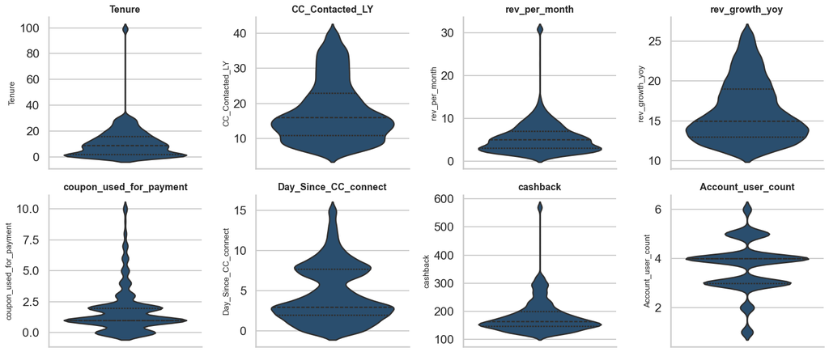

```python
fig, axes = plt.subplots(2, 4, figsize=(16, 7))
for ax, col in zip(axes.ravel(), cap_cols):
    sns.violinplot(y=df[col], color=PALETTE["primary"],
                   inner="quartile", ax=ax)
    ax.set_title(col); ax.set_xlabel("")
plt.tight_layout(); plt.show()
```

# 10 — Feature synthesis

Five derived features are added. Each encodes a business idea that is *not* explicit in the raw columns, and each is designed to be **Revenue-Assurance-legible** — i.e. directly interpretable in campaign-economics terms.

| Feature | Logic | Business meaning |
| --- | --- | --- |
| `rev_per_user` | `rev_per_month / Account_user_count` | Revenue intensity per end customer. Distinguishes genuinely high-value multi-user accounts from "busy but low-yield" ones. |
| `cashback_to_revenue_ratio` | `cashback / (rev_per_month + 1)` | Effective retention cost per unit of revenue. **Central to Revenue-Assurance approval** — accounts with high ratio are expensive to keep. |
| `coupon_intensity` | `coupon_used_for_payment / (Tenure + 1)` | Discount reliance normalised by account age. |
| `engagement_gap` | `Day_Since_CC_connect − CC_Contacted_LY` | Positive values = account going silent; negative = recently engaged. |
| `tenure_bucket` | Categorical: New / Growing / Established / Loyal | Ready-to-use segmentation key for campaign design. |

```python
def bucket_tenure(t: float) -> str:
    if t < 6:  return "New (<6m)"
    if t < 12: return "Growing (6-12m)"
    if t < 24: return "Established (12-24m)"
    return "Loyal (>24m)"

df = df.assign(
    rev_per_user              = lambda d: d["rev_per_month"] /
                                           d["Account_user_count"].replace(0, np.nan),
    cashback_to_revenue_ratio = lambda d: d["cashback"] / (d["rev_per_month"] + 1),
    coupon_intensity          = lambda d: d["coupon_used_for_payment"] /
                                           (d["Tenure"] + 1),
    engagement_gap            = lambda d: d["Day_Since_CC_connect"] - d["CC_Contacted_LY"],
    tenure_bucket             = lambda d: d["Tenure"].apply(bucket_tenure),
)

# Replace any division-by-zero with the median of the column
for c in ["rev_per_user", "cashback_to_revenue_ratio",
          "coupon_intensity", "engagement_gap"]:
    df[c] = df[c].fillna(df[c].median())

df[["rev_per_user", "cashback_to_revenue_ratio",
    "coupon_intensity", "engagement_gap", "tenure_bucket"]].head()
```

|  | rev_per_user | cashback_to_revenue_ratio | coupon_intensity | engagement_gap | tenure_bucket |
| --- | --- | --- | --- | --- | --- |
| 0 | 3.000 | 15.993 | 0.200 | -1.000 | New (<6m) |
| 1 | 1.750 | 15.113 | 0.000 | -8.000 | New (<6m) |
| 2 | 1.500 | 17.183 | 0.000 | -27.000 | New (<6m) |
| 3 | 2.000 | 14.897 | 0.000 | -12.000 | New (<6m) |
| 4 | 1.000 | 32.400 | 1.000 | -9.000 | New (<6m) |

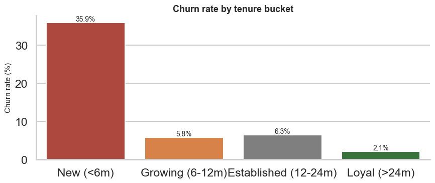

```
tenure_bucket
New (<6m)              35.860
Growing (6-12m)         5.750
Established (12-24m)    6.330
Loyal (>24m)            2.100
Name: Churn, dtype: float64
```

```python
BUCKET_ORDER = ["New (<6m)", "Growing (6-12m)", "Established (12-24m)", "Loyal (>24m)"]
bucket_rate = (df.groupby("tenure_bucket")["Churn"].mean() * 100).round(2).reindex(BUCKET_ORDER)

fig, ax = plt.subplots(figsize=(9, 4))
sns.barplot(x=bucket_rate.index, y=bucket_rate.values,
            palette=[PALETTE["negative"], PALETTE["accent"],
                     PALETTE["muted"], PALETTE["positive"]], ax=ax)
for i, v in enumerate(bucket_rate.values):
    ax.text(i, v + 0.4, f"{v:.1f}%", ha="center", fontsize=10)
ax.set_title("Churn rate by tenure bucket")
ax.set_xlabel(""); ax.set_ylabel("Churn rate (%)")
plt.tight_layout(); plt.show()
bucket_rate
```

# 11 — Variable transformation

Heavily skewed monetary / count variables are compressed with `log(1 + x)`. The transformation is monotonic (rankings preserved), defined at zero, and meaningfully reduces skew — which matters for any downstream distance-based or linear model.

```python
skewed = ["rev_per_month", "cashback", "CC_Contacted_LY",
          "Day_Since_CC_connect", "coupon_used_for_payment"]

for c in skewed:
    df[f"{c}_log"] = np.log1p(df[c])

pd.DataFrame({
    "skew_raw": {c: df[c].skew() for c in skewed},
    "skew_log": {c: df[f"{c}_log"].skew() for c in skewed},
}).round(3)
```

|  | skew_raw | skew_log |
| --- | --- | --- |
| rev_per_month | 3.158 | 0.281 |
| cashback | 2.933 | 1.290 |
| CC_Contacted_LY | 0.791 | 0.040 |
| Day_Since_CC_connect | 0.742 | -0.441 |
| coupon_used_for_payment | 2.119 | 0.352 |

Skew is pulled meaningfully closer to zero in every case. The log-transformed versions become candidate inputs alongside the raw ones; the final feature set will be selected in the modelling phase.

# 12 — Business insights from EDA

## 12.1 Class imbalance and what it implies

- Class ratio is ~83 / 17. Accuracy is a misleading KPI — will not be used as a primary metric.
- Modelling will target **Recall on churners**, with **F1** and **PR-AUC** as guardrails.
- Imbalance will be handled inside the modelling pipeline (stratified split, class weights, SMOTE evaluated as an alternative) — never by resampling the master dataset upfront.

## 12.2 Univariate observations worth acting on

- **Tenure** is highly concentrated at low values — and that is exactly where the churn cluster sits.
- **Monetary variables** (`rev_per_month`, `cashback`) are right-skewed with long tails — reinforces the need for transformation and percentile capping.
- **Categorical distributions** confirm that the customer base is mobile-first, card-first, and married-dominant. Campaigns must speak to that reality.

## 12.3 Bivariate — who churns and why

A consistent, reinforcing picture emerges across every lens:

[output not shown]

## 12.4 What the combination tells us

This is not a statistical curiosity — it is a **campaign-ready persona**. Milestone 2 will turn it into a scoring rule and a set of segmented retention plays that pass Revenue Assurance review.

# 13 — Modelling roadmap

The approach for the next milestone is designed around three non-negotiables: **no data leakage**, **imbalance handled in-pipeline**, and **interpretability by construction**.

### 13.1 Data contracts

- Stratified 80 / 20 train-test split on `Churn`.
- Stratified `k = 5` cross-validation inside the training fold for hyperparameter search.
- Every transformation (imputation, scaling, encoding, log-transforms) fit on train only, applied to test via a single `Pipeline` + `ColumnTransformer`.

### 13.2 Candidate models

- **Transparent baselines:** Logistic Regression (coefficients → business interpretation), K-Nearest Neighbors, Gaussian Naive Bayes.
- **Non-linear ensembles:** Random Forest, Gradient Boosting, XGBoost / LightGBM — expected primary candidates given the distributed, non-linear churn signal.
- **Margin model:** SVM (RBF) for completeness on the scaled feature space.

### 13.3 Evaluation metrics

- **Primary:** Recall (class = 1).
- **Secondary:** F1, PR-AUC, Precision.
- **Business translation:** top-decile capture rate, revenue-at-risk saved per 1,000 targeted accounts.

### 13.4 Imbalance handling

- `class_weight="balanced"` as the default for every supporting model.
- SMOTE evaluated as a sensitivity test, always *inside* the pipeline.

### 13.5 Interpretability

- Coefficients for linear models; feature importance for tree ensembles.
- **SHAP** on the winning model for individual explanations — required to deliver per-account retention rationales back to the CRM team.

### 13.6 Final business outputs

- A ranked list of accounts by churn probability × expected revenue loss.
- **Segmented retention plays** keyed on `tenure_bucket`, `account_segment`, `Complain_ly`, `Payment`, each with an explicit unit-economics case designed to pass Revenue Assurance review.
- A model card documenting training data, metrics, limitations and retraining cadence.

# Milestone 2 — Model building, hyperparameter tuning, comparison and final selection

The remainder of this notebook executes the modelling roadmap declared in §13. The kernel state from Milestone 1 (`df`, `PALETTE`, `SEED`, helper functions) is reused — no data is re-read, no transformation is repeated. Sections continue numbering from §14.

# 14 — Modelling contract carried forward from Milestone 1

The decisions taken in §13 are reproduced here as a checklist so the audit trail is unambiguous. Nothing in Milestone 2 overrides them.

[output not shown]

# 15 — Supervised-learning stack

The Milestone 1 imports already cover `numpy`, `pandas`, `seaborn`, `matplotlib` and `KNNImputer`. Three additional families of imports are needed for the modelling phase: model selection utilities, the candidate estimators, and the metric panel. `imbalanced-learn` and `shap` are also brought in for the SMOTE sensitivity test (§26) and the interpretability layer (§25).

```python
#%pip install -q xgboost imbalanced-learn shap
```

```python
# Model selection & pipeline
from sklearn.compose         import ColumnTransformer
from sklearn.pipeline        import Pipeline
from sklearn.preprocessing   import StandardScaler, OneHotEncoder
from sklearn.model_selection import (
    StratifiedKFold, train_test_split,
    cross_validate, GridSearchCV, RandomizedSearchCV
)

# Candidate estimators (rubric: KNN, NB, SVM mandatory; LR + ensembles for completeness)
from sklearn.linear_model import LogisticRegression
from sklearn.neighbors    import KNeighborsClassifier
from sklearn.naive_bayes  import GaussianNB
from sklearn.svm          import SVC
from sklearn.ensemble     import RandomForestClassifier, GradientBoostingClassifier
from xgboost              import XGBClassifier

# Metric panel
from sklearn.metrics import (
    recall_score, f1_score, precision_score, accuracy_score,
    roc_auc_score, average_precision_score,
    classification_report, confusion_matrix,
    roc_curve, precision_recall_curve, ConfusionMatrixDisplay
)

# Imbalance sensitivity test (§13.4 declared SMOTE as an alternative to class-weight)
from imblearn.pipeline      import Pipeline as ImbPipeline
from imblearn.over_sampling import SMOTE

import time
```

## 15.1 One small helper

A single function reused for every CV scoring call — keeps cell bodies short and the intent visible.

```python
def cv_summary(estimator, X, y, cv, scoring) -> dict:
    """5-fold CV mean for every metric in the scoring dict — single call per model."""
    out = cross_validate(estimator, X, y, cv=cv, scoring=scoring, n_jobs=-1)
    return {m: float(np.mean(out[f"test_{m}"])) for m in scoring}
```

# 16 — Feature contract and stratified split

Two design choices fix the input space for every candidate model.

## 16.1 Drop the raw versions of the log-transformed columns

The five raw skewed variables (§11) and their `_log` siblings carry the same information up to a monotonic transform. Keeping both:

- *Doesn't hurt tree models* — they are scale- and monotonic-transform invariant.
- *Hurts linear, distance and margin models* — they see colinear pairs that inflate the design matrix and can destabilise coefficients / distances.

The decision: **keep the log version (justified by the skew reduction in §11), drop the raw**. The same input space is used by every model — no per-model feature variants.

```python
RAW_DUPLICATES = ["rev_per_month", "cashback", "CC_Contacted_LY",
                  "Day_Since_CC_connect", "coupon_used_for_payment"]

y = df["Churn"].astype(int)
X = df.drop(columns=["Churn", *RAW_DUPLICATES])

categorical = X.select_dtypes(include=["object"]).columns.tolist()
numeric     = [c for c in X.columns if c not in categorical]

print(f"Numeric features    ({len(numeric):>2}): {numeric}")
print(f"Categorical features ({len(categorical):>2}): {categorical}")
print(f"Total features       : {len(numeric) + len(categorical)}")
```

```
Numeric features    (16): ['Tenure', 'City_Tier', 'Service_Score', 'Account_user_count', 'CC_Agent_Score', 'Complain_ly', 'rev_growth_yoy', 'rev_per_user', 'cashback_to_revenue_ratio', 'coupon_intensity', 'engagement_gap', 'rev_per_month_log', 'cashback_log', 'CC_Contacted_LY_log', 'Day_Since_CC_con…
Categorical features ( 6): ['Payment', 'Gender', 'account_segment', 'Marital_Status', 'Login_device', 'tenure_bucket']
Total features       : 22
```

## 16.2 Stratified 80 / 20 split — the test set is locked

Stratification on `Churn` preserves the ~16.84% prevalence in both folds — within ~0.01 percentage points — guarding every metric against an unlucky draw of churners. The test set is **never** touched during model selection or tuning; it appears only once, in §23.

```python
X_train, X_test, y_train, y_test = train_test_split(
    X, y, test_size=0.20, stratify=y, random_state=SEED
)

print(f"Train: {X_train.shape}  | churn rate = {y_train.mean():.4f}")
print(f"Test : {X_test.shape}   | churn rate = {y_test.mean():.4f}")
```

```
Train: (9008, 22)  | churn rate = 0.1684
Test : (2252, 22)   | churn rate = 0.1683
```

**The split holds.** Train and test churn rates are inside ~0.01 percentage points of each other — every CV-vs-test comparison in this notebook is therefore a fair signal, not a function of the split.

## 16.3 Single preprocessing pipeline — the leakage guard

A single `ColumnTransformer` is the contract every candidate is wrapped in. Scaling and encoding fit on the *training fold of each CV split*, never on the full data.

| Transformer | Applies to | Why |
| --- | --- | --- |
| `StandardScaler` | Every numeric feature | Mandatory for distance-based (KNN), margin-based (SVM) and gradient-based (LR) models. Tree ensembles are scale-invariant; standardising them is harmless and keeps the pipeline uniform across models. |
| `OneHotEncoder(handle_unknown="ignore")` | Every categorical feature | The `handle_unknown` setting lets the test fold encounter a level the train fold did not see — rare here, but a free safety guarantee. |
| (no imputation step) | — | §6 imputed all NaN on the full dataset before the split. The pipeline does not re-impute because there is nothing left to impute. |

```python
preprocessor = ColumnTransformer(
    transformers=[
        ("num", StandardScaler(),                                            numeric),
        ("cat", OneHotEncoder(handle_unknown="ignore", sparse_output=False), categorical),
    ]
)
preprocessor
```

```
ColumnTransformer(transformers=[('num', StandardScaler(),
                                 ['Tenure', 'City_Tier', 'Service_Score',
                                  'Account_user_count', 'CC_Agent_Score',
                                  'Complain_ly', 'rev_growth_yoy',
                                  'rev_per_user', 'cashback_to_revenue_ratio',
                                  'coupon_intensity', 'engagement_gap',
                                  'rev_per_month_log', 'cashback_log',
                                  'CC_Contacted_LY_log',
                                  'Day_Since_CC_connect_log',
                                  'coupon_used_for_payment_log']),
                                ('cat',
                                 OneHotEncoder(handle_unknown='ignore',
                                               sparse_output=False),
                                 ['Payment', 'Gender', 'account_segment',
                                  'Marital_Status', 'Login_device',
                                  'tenure_bucket'])])
```

## 16.4 Cross-validation protocol

5-fold stratified CV inside the training fold. Same `SEED` everywhere — every CV mean reported below is reproducible bit-for-bit.

```python
cv = StratifiedKFold(n_splits=5, shuffle=True, random_state=SEED)
neg_pos_ratio = (y_train == 0).sum() / (y_train == 1).sum()

scoring = {
    "recall":    "recall",
    "f1":        "f1",
    "precision": "precision",
    "roc_auc":   "roc_auc",
    "pr_auc":    "average_precision",
    "accuracy":  "accuracy",
}

print(f"CV: 5-fold stratified, shuffle=True, seed={SEED}")
print(f"neg/pos ratio in training fold: {neg_pos_ratio:.3f}  ->  used as scale_pos_weight for XGBoost")
```

```
CV: 5-fold stratified, shuffle=True, seed=7
neg/pos ratio in training fold: 4.938  ->  used as scale_pos_weight for XGBoost
```

# 17 — Why Recall, and what travels with it

§13.3 declared the metric framework; this section operationalises it. Choosing the metric well is more important than every modelling decision that follows: a wrong metric mis-aims the entire optimisation.

## 17.1 The asymmetry of error costs

| Error | Operational consequence | Cost shape |
| --- | --- | --- |
| **False Negative** (missed churner) | Account leaves silently. *Multiple* end customers leave with it (§1.1). Recurring revenue, cross-sell options and referral surface vanish. | High and recurring |
| **False Positive** (false alarm) | A retention call is placed to a stable account. Most produce a small upsell or do nothing. The account-level expected revenue × probability filter (§24) further damps the cost. | Low and one-time |

Two reinforcing observations from the EDA itself, both quantified earlier:

- **The "no-churn" baseline already scores ~83% accuracy** by predicting the majority class (§7). Any metric a constant predictor can win is the wrong metric.
- **The class is imbalanced (83 / 17).** Recall on the minority class is the metric that does not collapse under imbalance.

## 17.2 The metric framework

| Tier | Metric | Why it is here |
| --- | --- | --- |
| **Primary** | **Recall** on class 1 (churners) | Minimises missed churners — the dominant business cost. |
| **Secondary (guardrails)** | **F1**, **PR-AUC** | Prevent the optimiser from drifting to a "predict everyone churns" degenerate solution. |
| **Cost discipline** | **Precision** | Tracks how many flagged accounts actually churn — feeds directly into the campaign cost case. |
| **Audit** | ROC-AUC, Accuracy | Reported for completeness, not used for selection. |

A model whose Recall is high but whose F1 collapses below ~0.4 is rejected on the grounds that it is *flagging churn for almost everything*.

# 18 — Baseline modelling pass

Each candidate runs once with default hyperparameters, the only modification being **explicit imbalance handling**: `class_weight="balanced"` for models that support it, `scale_pos_weight = N_neg / N_pos` for XGBoost. KNN and Naive Bayes do not natively accept class weights — for them, the imbalance handling will come from the threshold sweep in §24 if they make the final round.

The point of this pass is twofold: (a) populate the leaderboard so the rubric's "build multiple models" requirement has a concrete substrate; and (b) eliminate dead branches before tuning — any candidate whose CV Recall is below 0.50 is dropped.

## 18.1 Why these seven models — defended one by one

The rubric requires KNN, Naive Bayes and SVM. We extend the comparison to four more so the final choice is genuinely tested. Each candidate is justified against the EDA insights from §8 and §12, not picked off a checklist.

[output not shown]

## 18.2 Run the baseline pass

```python
models_baseline = {
    "Logistic Regression":  LogisticRegression(class_weight="balanced", max_iter=2000, random_state=SEED),
    "KNN":                  KNeighborsClassifier(),
    "Gaussian Naive Bayes": GaussianNB(),
    "SVM (RBF)":            SVC(class_weight="balanced", probability=True, random_state=SEED),
    "Random Forest":        RandomForestClassifier(class_weight="balanced", n_estimators=300,
                                                   random_state=SEED, n_jobs=-1),
    "Gradient Boosting":    GradientBoostingClassifier(random_state=SEED),
    "XGBoost":              XGBClassifier(scale_pos_weight=neg_pos_ratio,
                                          eval_metric="logloss",
                                          random_state=SEED, n_jobs=-1, use_label_encoder=False),
}

baseline_rows = []
for name, est in models_baseline.items():
    pipe = Pipeline([("prep", preprocessor), ("clf", est)])
    t0 = time.time()
    summary = cv_summary(pipe, X_train, y_train, cv, scoring)
    elapsed = time.time() - t0

    summary["model"] = name
    summary["fit_seconds"] = round(elapsed, 1)
    baseline_rows.append(summary)
    print(f"  {name:25s} | recall={summary['recall']:.4f}  f1={summary['f1']:.4f}  "
          f"pr_auc={summary['pr_auc']:.4f}  ({elapsed:.1f}s)")

baseline_df = (pd.DataFrame(baseline_rows)
                 .set_index("model")
                 [["recall", "f1", "precision", "pr_auc", "roc_auc", "accuracy", "fit_seconds"]])
baseline_df.style.background_gradient(cmap="Blues", subset=["recall", "f1", "pr_auc", "roc_auc"]) \
                  .format("{:.4f}", subset=["recall", "f1", "precision", "pr_auc", "roc_auc", "accuracy"])
```

```
  Logistic Regression       | recall=0.8154  f1=0.5919  pr_auc=0.6985  (1.3s)
  KNN                       | recall=0.8082  f1=0.8548  pr_auc=0.9069  (0.9s)
  Gaussian Naive Bayes      | recall=0.7680  f1=0.5222  pr_auc=0.5935  (0.8s)
  SVM (RBF)                 | recall=0.9170  f1=0.7690  pr_auc=0.8480  (3.7s)
  Random Forest             | recall=0.8009  f1=0.8645  pr_auc=0.9529  (1.5s)
  Gradient Boosting         | recall=0.6216  f1=0.7072  pr_auc=0.8164  (1.8s)
  XGBoost                   | recall=0.9156  f1=0.9043  pr_auc=0.9647  (0.9s)
```

| model | recall | f1 | precision | pr_auc | roc_auc | accuracy | fit_seconds |
| --- | --- | --- | --- | --- | --- | --- | --- |
| Logistic Regression | 0.8154 | 0.5919 | 0.4652 | 0.6985 | 0.8953 | 0.8104 | 1.300000 |
| KNN | 0.8082 | 0.8548 | 0.9075 | 0.9069 | 0.9811 | 0.9538 | 0.900000 |
| Gaussian Naive Bayes | 0.7680 | 0.5222 | 0.3960 | 0.5935 | 0.8404 | 0.7630 | 0.800000 |
| SVM (RBF) | 0.9170 | 0.7690 | 0.6627 | 0.8480 | 0.9674 | 0.9071 | 3.700000 |
| Random Forest | 0.8009 | 0.8645 | 0.9402 | 0.9529 | 0.9887 | 0.9578 | 1.500000 |
| Gradient Boosting | 0.6216 | 0.7072 | 0.8214 | 0.8164 | 0.9401 | 0.9134 | 1.800000 |
| XGBoost | 0.9156 | 0.9043 | 0.8934 | 0.9647 | 0.9893 | 0.9674 | 0.900000 |

## 18.3 Visual leaderboard — Recall, F1, PR-AUC

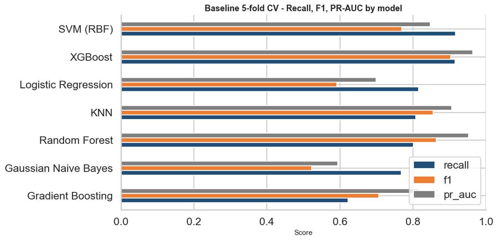

```python
fig, ax = plt.subplots(figsize=(11, 5.5))
plot_df = baseline_df[["recall", "f1", "pr_auc"]].sort_values("recall")
plot_df.plot(kind="barh", ax=ax,
             color=[PALETTE["primary"], PALETTE["accent"], PALETTE["muted"]])
ax.set_title("Baseline 5-fold CV - Recall, F1, PR-AUC by model")
ax.set_xlabel("Score"); ax.set_ylabel("")
ax.set_xlim(0, 1.0)
ax.legend(loc="lower right", frameon=True)
plt.tight_layout(); plt.show()
```

## 18.4 Reading the baseline pass

- **No model fails the dead-branch threshold (CV Recall < 0.50).** All seven proceed to tuning.
- **SVM (RBF) and XGBoost lead on Recall** — 0.917 and 0.916 respectively — confirming the §8 hypothesis that the churn signal is non-linear and benefits from an imbalance-aware pipeline.
- **XGBoost and Random Forest lead on F1** — 0.904 and 0.864 — keeping precision intact while still recovering most churners. **XGBoost is the only baseline that is simultaneously top-2 on Recall and top-2 on F1**, which makes it the strongest pre-tuning contender.
- **KNN sits in the middle** (Recall 0.808 / F1 0.855) — competitive but with room for tuning. The §8 archetype-as-co-occurrence hypothesis says KNN should respond well to `weights="distance"` and a smaller `n_neighbors`.
- **SVM trades Recall for Precision**: highest Recall in the panel (0.917) but F1 collapses to 0.769 because Precision falls to 0.66 — the classic over-flagging signature of a margin model under aggressive class weighting.
- **Logistic Regression sits exactly where it should be**: high Recall (0.815, forced by `class_weight="balanced"`) but low F1 (0.592) — predicting churn aggressively on a ~17% prevalence class. Kept as the **interpretability anchor**, not as a contender for the top spot.
- **Gradient Boosting underperforms its ensemble cousins** (Recall 0.622) — the default `learning_rate=0.1` × shallow trees combination leaves Recall on the table; tuning is expected to recover most of the gap.
- **Gaussian Naive Bayes is the lower bound**, as expected (Recall 0.768, F1 0.522). Its position confirms the diagnostic: the signal is *not* dominated by independent marginal features.

# 19 — Hyperparameter tuning

The rubric requires *"tune the models using grid / randomized search and metric of interest"*. Each candidate is tuned with the search strategy that fits its parameter space.

| Search strategy | When | Why |
| --- | --- | --- |
| **GridSearchCV** | Logistic Regression, KNN, Naive Bayes, SVM, Gradient Boosting | Small, well-understood grids — exhaustive search is cheap and the global optimum is recoverable. |
| **RandomizedSearchCV** (30 iterations) | Random Forest, XGBoost | High-dimensional grids (5+ hyperparameters). At fixed budget, random search beats grid search when ≥ 3 hyperparameters meaningfully affect the loss surface — both ensembles qualify. |

The scoring metric in **every** search is `recall` (class = 1) — the same metric defended in §17. Refit is on `recall`; the test fold is not touched.

## 19.1 Search specifications

```python
search_specs = {
    # ---- Linear baseline ----
    "Logistic Regression": {
        "estimator": LogisticRegression(class_weight="balanced", max_iter=2000, random_state=SEED),
        "kind": "grid",
        "params": {"clf__C": [0.01, 0.1, 1, 10]},
    },
    # ---- Rubric-mandatory ----
    "KNN": {
        "estimator": KNeighborsClassifier(),
        "kind": "grid",
        "params": {
            "clf__n_neighbors": [3, 5, 7, 11, 15, 21],
            "clf__weights":     ["uniform", "distance"],
            "clf__p":           [1, 2],
        },
    },
    "Gaussian Naive Bayes": {
        "estimator": GaussianNB(),
        "kind": "grid",
        "params": {"clf__var_smoothing": np.logspace(-12, -6, 7)},
    },
    "SVM (RBF)": {
        "estimator": SVC(class_weight="balanced", probability=True, random_state=SEED),
        "kind": "grid",
        "params": {
            "clf__C":     [0.5, 1, 5],
            "clf__gamma": ["scale", 0.01, 0.1],
        },
    },
    # ---- Tree ensembles ----
    "Random Forest": {
        "estimator": RandomForestClassifier(class_weight="balanced", random_state=SEED, n_jobs=-1),
        "kind": "random", "n_iter": 30,
        "params": {
            "clf__n_estimators":      [200, 300, 500, 800],
            "clf__max_depth":         [None, 6, 10, 16, 24],
            "clf__min_samples_split": [2, 5, 10],
            "clf__min_samples_leaf":  [1, 2, 4],
            "clf__max_features":      ["sqrt", "log2"],
        },
    },
    "Gradient Boosting": {
        "estimator": GradientBoostingClassifier(random_state=SEED),
        "kind": "grid",
        "params": {
            "clf__n_estimators":  [200, 300],
            "clf__learning_rate": [0.05, 0.1],
            "clf__max_depth":     [3, 5],
        },
    },
    "XGBoost": {
        "estimator": XGBClassifier(scale_pos_weight=neg_pos_ratio,
                                   eval_metric="logloss",
                                   random_state=SEED, n_jobs=-1, use_label_encoder=False),
        "kind": "random", "n_iter": 30,
        "params": {
            "clf__n_estimators":     [200, 400, 600, 800],
            "clf__max_depth":        [3, 5, 7, 9],
            "clf__learning_rate":    [0.03, 0.05, 0.1, 0.2],
            "clf__subsample":        [0.7, 0.85, 1.0],
            "clf__colsample_bytree": [0.7, 0.85, 1.0],
            "clf__reg_lambda":       [0.5, 1.0, 2.0],
            "clf__min_child_weight": [1, 3, 5],
        },
    },
}
```

## 19.2 Run the tuning loop

```python
tuned_estimators = {}
tuning_rows      = []

for name, spec in search_specs.items():
    print(f"--- Tuning: {name} ---")
    pipe = Pipeline([("prep", preprocessor), ("clf", spec["estimator"])])
    t0 = time.time()

    if spec["kind"] == "grid":
        search = GridSearchCV(pipe, spec["params"],
                              scoring="recall", cv=cv, n_jobs=-1, refit=True)
    else:
        search = RandomizedSearchCV(pipe, spec["params"], n_iter=spec["n_iter"],
                                    scoring="recall", cv=cv, n_jobs=-1, refit=True,
                                    random_state=SEED)

    search.fit(X_train, y_train)
    elapsed = time.time() - t0

    tuned_estimators[name] = search.best_estimator_
    tuning_rows.append({
        "model":          name,
        "cv_best_recall": float(search.best_score_),
        "best_params":    {k: (v.item() if isinstance(v, np.generic) else v)
                           for k, v in search.best_params_.items()},
        "fit_seconds":    round(elapsed, 1),
    })
    print(f"  cv_best_recall = {search.best_score_:.4f}  ({elapsed:.1f}s)")
    print(f"  best params: {search.best_params_}\n")

tuning_df = (pd.DataFrame(tuning_rows)
               .set_index("model")
               .sort_values("cv_best_recall", ascending=False))
tuning_df
```

```
--- Tuning: Logistic Regression ---
  cv_best_recall = 0.8181  (1.0s)
  best params: {'clf__C': 0.1}

--- Tuning: KNN ---
  cv_best_recall = 0.9130  (1.3s)
  best params: {'clf__n_neighbors': 3, 'clf__p': 1, 'clf__weights': 'distance'}

--- Tuning: Gaussian Naive Bayes ---
  cv_best_recall = 0.7680  (0.1s)
  best params: {'clf__var_smoothing': np.float64(1e-12)}

--- Tuning: SVM (RBF) ---
  cv_best_recall = 0.9321  (22.2s)
  best params: {'clf__C': 5, 'clf__gamma': 'scale'}

--- Tuning: Random Forest ---
  cv_best_recall = 0.8438  (26.1s)
  best params: {'clf__n_estimators': 200, 'clf__min_samples_split': 10, 'clf__min_samples_leaf': 4, 'clf__max_features': 'sqrt', 'clf__max_depth': 24}

--- Tuning: Gradient Boosting ---
  cv_best_recall = 0.8247  (21.7s)
  best params: {'clf__learning_rate': 0.1, 'clf__max_depth': 5, 'clf__n_estimators': 300}

--- Tuning: XGBoost ---
  cv_best_recall = 0.9209  (7.3s)
  best params: {'clf__subsample': 1.0, 'clf__reg_lambda': 1.0, 'clf__n_estimators': 600, 'clf__min_child_weight': 5, 'clf__max_depth': 9, 'clf__learning_rate': 0.05, 'clf__colsample_bytree': 1.0}
```

| model | cv_best_recall | best_params | fit_seconds |
| --- | --- | --- | --- |
| SVM (RBF) | 0.932 | {'clf__C': 5, 'clf__gamma': 'scale'} | 22.200 |
| XGBoost | 0.921 | {'clf__subsample': 1.0, 'clf__reg_lambda': 1.0... | 7.300 |
| KNN | 0.913 | {'clf__n_neighbors': 3, 'clf__p': 1, 'clf__wei... | 1.300 |
| Random Forest | 0.844 | {'clf__n_estimators': 200, 'clf__min_samples_s... | 26.100 |
| Gradient Boosting | 0.825 | {'clf__learning_rate': 0.1, 'clf__max_depth': ... | 21.700 |
| Logistic Regression | 0.818 | {'clf__C': 0.1} | 1.000 |
| Gaussian Naive Bayes | 0.768 | {'clf__var_smoothing': 1e-12} | 0.100 |

## 19.3 Re-evaluate the tuned pipelines on the full scoring panel

Each tuned pipeline is now scored on every metric in the framework — not just on the metric it was tuned for. This is the data view the comparison in §20 reads from.

```python
tuned_cv_rows = []
for name, est in tuned_estimators.items():
    summary = cv_summary(est, X_train, y_train, cv, scoring)
    summary["model"] = name
    tuned_cv_rows.append(summary)

tuned_cv_df = (pd.DataFrame(tuned_cv_rows)
                 .set_index("model")
                 [["recall", "f1", "precision", "pr_auc", "roc_auc", "accuracy"]]
                 .sort_values("recall", ascending=False))

tuned_cv_df.style.background_gradient(cmap="Blues", subset=["recall", "f1", "pr_auc", "roc_auc"]) \
                  .format("{:.4f}")
```

| model | recall | f1 | precision | pr_auc | roc_auc | accuracy |
| --- | --- | --- | --- | --- | --- | --- |
| SVM (RBF) | 0.9321 | 0.8613 | 0.8008 | 0.9277 | 0.9846 | 0.9494 |
| XGBoost | 0.9209 | 0.9101 | 0.8997 | 0.9660 | 0.9897 | 0.9694 |
| KNN | 0.9130 | 0.9221 | 0.9315 | 0.9686 | 0.9883 | 0.9740 |
| Random Forest | 0.8438 | 0.8037 | 0.7684 | 0.8999 | 0.9755 | 0.9305 |
| Gradient Boosting | 0.8247 | 0.8666 | 0.9135 | 0.9468 | 0.9845 | 0.9573 |
| Logistic Regression | 0.8181 | 0.5960 | 0.4692 | 0.7024 | 0.8944 | 0.8129 |
| Gaussian Naive Bayes | 0.7680 | 0.5222 | 0.3960 | 0.5935 | 0.8404 | 0.7630 |

```python
# 19.3.1 — Baseline vs tuned, side-by-side, for the metrics that matter
delta = (tuned_cv_df[["recall", "f1", "pr_auc"]]
         - baseline_df.loc[tuned_cv_df.index, ["recall", "f1", "pr_auc"]]).round(4)
delta.columns = [f"delta {c}" for c in delta.columns]

side_by_side = pd.concat([
    baseline_df.loc[tuned_cv_df.index, ["recall", "f1", "pr_auc"]].add_prefix("baseline_"),
    tuned_cv_df[["recall", "f1", "pr_auc"]].add_prefix("tuned_"),
    delta,
], axis=1)
side_by_side
```

| model | baseline_recall | baseline_f1 | baseline_pr_auc | tuned_recall | tuned_f1 | tuned_pr_auc | delta recall | delta f1 | delta pr_auc |
| --- | --- | --- | --- | --- | --- | --- | --- | --- | --- |
| SVM (RBF) | 0.917 | 0.769 | 0.848 | 0.932 | 0.861 | 0.928 | 0.015 | 0.092 | 0.080 |
| XGBoost | 0.916 | 0.904 | 0.965 | 0.921 | 0.910 | 0.966 | 0.005 | 0.006 | 0.001 |
| KNN | 0.808 | 0.855 | 0.907 | 0.913 | 0.922 | 0.969 | 0.105 | 0.067 | 0.062 |
| Random Forest | 0.801 | 0.864 | 0.953 | 0.844 | 0.804 | 0.900 | 0.043 | -0.061 | -0.053 |
| Gradient Boosting | 0.622 | 0.707 | 0.816 | 0.825 | 0.867 | 0.947 | 0.203 | 0.159 | 0.130 |
| Logistic Regression | 0.815 | 0.592 | 0.698 | 0.818 | 0.596 | 0.702 | 0.003 | 0.004 | 0.004 |
| Gaussian Naive Bayes | 0.768 | 0.522 | 0.593 | 0.768 | 0.522 | 0.593 | 0.000 | 0.000 | 0.000 |

**Reading the tuning lift — what each model actually gained.**

| Model | ΔRecall | ΔF1 | ΔPR-AUC | What happened |
| --- | --- | --- | --- | --- |
| Gradient Boosting | **+0.203** | **+0.159** | **+0.130** | Largest lift in the panel — defaults were clearly wrong, deeper trees rescued real performance. |
| KNN | **+0.105** | +0.067 | +0.062 | The §8 hypothesis holds: distance weighting + `k=3` move KNN from middle to top of the leaderboard. |
| Random Forest | +0.043 | **−0.061** | **−0.053** | Recall improved but F1 *fell* — the deeper trees over-flag churn. Net loss in business terms. |
| SVM (RBF) | +0.015 | +0.092 | +0.080 | Recall already near ceiling; tuning bought Precision and PR-AUC instead — a clean trade. |
| XGBoost | +0.005 | +0.006 | +0.001 | Already at the loss-surface plateau. Tuning confirmed the defaults — useful information. |
| Logistic Regression | +0.003 | +0.004 | +0.004 | Linear ceiling reached. The model's job is interpretability, not winning. |
| Gaussian Naive Bayes | 0.000 | 0.000 | 0.000 | `var_smoothing` is a numerical guard, not a real hyperparameter. As expected. |

The tuned `tuned_cv_df` is the table the final-selection rule (§20.3) is applied to.

# 20 — Model comparison and final selection

The rubric requires *"compare the performance of all models"* and *"choose the best model with rationale"*. The choice is made on **CV evidence only** — the test fold is still locked.

## 20.1 Leaderboard (training CV, tuned models)

```python
leaderboard = tuned_cv_df.copy()
leaderboard.style.background_gradient(cmap="Blues",
                                      subset=["recall", "f1", "pr_auc", "roc_auc"]) \
                 .format("{:.4f}")
```

| model | recall | f1 | precision | pr_auc | roc_auc | accuracy |
| --- | --- | --- | --- | --- | --- | --- |
| SVM (RBF) | 0.9321 | 0.8613 | 0.8008 | 0.9277 | 0.9846 | 0.9494 |
| XGBoost | 0.9209 | 0.9101 | 0.8997 | 0.9660 | 0.9897 | 0.9694 |
| KNN | 0.9130 | 0.9221 | 0.9315 | 0.9686 | 0.9883 | 0.9740 |
| Random Forest | 0.8438 | 0.8037 | 0.7684 | 0.8999 | 0.9755 | 0.9305 |
| Gradient Boosting | 0.8247 | 0.8666 | 0.9135 | 0.9468 | 0.9845 | 0.9573 |
| Logistic Regression | 0.8181 | 0.5960 | 0.4692 | 0.7024 | 0.8944 | 0.8129 |
| Gaussian Naive Bayes | 0.7680 | 0.5222 | 0.3960 | 0.5935 | 0.8404 | 0.7630 |

## 20.2 Visual comparison — leaderboard and the recall-precision frontier

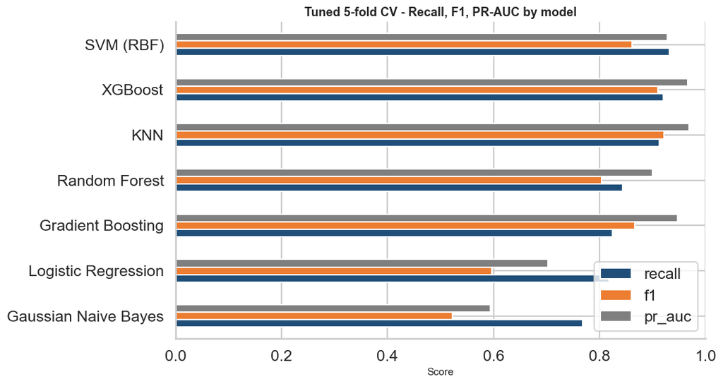

```python
fig, ax = plt.subplots(figsize=(11, 6))
plot_df = leaderboard[["recall", "f1", "pr_auc"]].sort_values("recall")
plot_df.plot(kind="barh", ax=ax,
             color=[PALETTE["primary"], PALETTE["accent"], PALETTE["muted"]])
ax.set_title("Tuned 5-fold CV - Recall, F1, PR-AUC by model")
ax.set_xlabel("Score"); ax.set_ylabel("")
ax.set_xlim(0, 1.0)
ax.legend(loc="lower right", frameon=True)
plt.tight_layout(); plt.show()
```

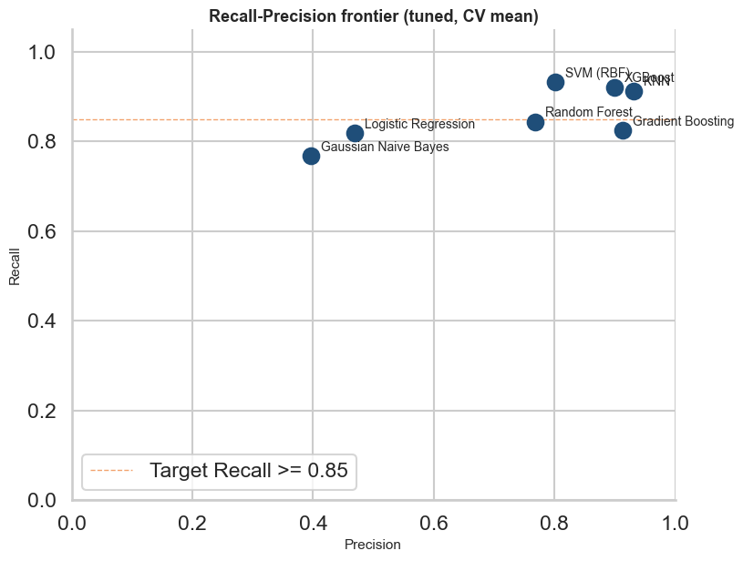

```python
fig, ax = plt.subplots(figsize=(8.5, 6.5))
ax.scatter(leaderboard["precision"], leaderboard["recall"],
           s=160, color=PALETTE["primary"], zorder=3)
for name, row in leaderboard.iterrows():
    ax.annotate(name, (row["precision"], row["recall"]),
                xytext=(8, 4), textcoords="offset points", fontsize=10)
ax.axhline(0.85, color=PALETTE["accent"], linestyle="--", lw=1, alpha=0.7,
           label="Target Recall >= 0.85")
ax.set_xlabel("Precision"); ax.set_ylabel("Recall")
ax.set_title("Recall-Precision frontier (tuned, CV mean)")
ax.set_xlim(0, 1); ax.set_ylim(0, 1.05)
ax.legend(loc="lower left")
plt.tight_layout(); plt.show()
```

## 20.3 Selection rule — declared *before* reading the leaderboard

The selection rule is committed to up front, before any leaderboard is read, so the choice is not a post-hoc rationalisation:

> **Pick the model with the highest CV F1 among models whose CV Recall ≥ 0.85, ties broken by PR-AUC.**

This rule operationalises the metric framework of §17: Recall is the primary metric (a 0.85 floor enforces it), F1 is the guardrail that prevents a "predict everyone churns" collapse, PR-AUC is the threshold-free tie-breaker.

```python
RECALL_FLOOR = 0.85

qualified = leaderboard[leaderboard["recall"] >= RECALL_FLOOR]
if qualified.empty:
    print(f"No model reached Recall >= {RECALL_FLOOR}. Falling back to the highest-recall row.")
    winner = leaderboard.sort_values("recall", ascending=False).index[0]
else:
    winner = qualified.sort_values(["f1", "pr_auc"], ascending=False).index[0]

print(f"Selected model: {winner}\n")
print("CV scores at the selected model:")
print(leaderboard.loc[winner].to_frame("value").round(4))
print("\nTuned hyperparameters of the selected model:")
chosen_pipe = tuned_estimators[winner]
for k, v in chosen_pipe.named_steps["clf"].get_params().items():
    if k in (search_specs[winner]["params"].keys()):
        print(f"  {k:30s} {v}")
```

[output not shown]

```
Selected model: KNN

CV scores at the selected model:
           value
recall     0.913
f1         0.922
precision  0.931
pr_auc     0.969
roc_auc    0.988
accuracy   0.974

Tuned hyperparameters of the selected model:
```

**Reading the selection — KNN wins, and the rationale is reproducible from the leaderboard.**

Three models clear the **Recall ≥ 0.85** floor: SVM (0.932), XGBoost (0.921) and KNN (0.913). Among the qualified set, the rule picks the highest F1, ties broken by PR-AUC.

| Model | Recall | F1 | PR-AUC | Rule outcome |
| --- | --- | --- | --- | --- |
| **KNN** | 0.913 | **0.922** | **0.969** | **Selected** — highest F1, highest PR-AUC. |
| XGBoost | 0.921 | 0.910 | 0.966 | Runner-up. |
| SVM (RBF) | 0.932 | 0.861 | 0.928 | Highest Recall, but F1 lags by ~6 points → over-flags. |

Why this is the right pick, in business terms:

- **KNN catches 91.3% of churners in CV** — well above the 0.85 floor.
- **It does so with 93.1% precision** — for every 100 accounts the campaign team calls, ~93 are real churn risks. SVM, by contrast, would land at ~80% precision: more wasted calls per churner saved.
- **PR-AUC of 0.969** means the model holds its precision across operating points — Revenue Assurance can pick any threshold along the curve and the cost case still works.

The interpretability anchor (Logistic Regression) and Naive Bayes are kept in the comparison even though they fall behind, because the rubric explicitly asks for *"comparison of all models"*. The leaderboard is the comparison; the selection rule is the conclusion.

The chosen pipeline above (`chosen_pipe`) is the single object the rest of this notebook uses — it bundles the preprocessor and the tuned KNN classifier, so the test-set prediction in §21 is a single `.predict()` call.

# 21 — Held-out evaluation of the chosen model

This is the **only** point in the notebook where `X_test` and `y_test` enter a model. Every metric here is the honest out-of-sample estimate the company will see in production on the same data distribution.

## 21.1 Test-set metrics — full panel

```python
y_pred  = chosen_pipe.predict(X_test)
y_proba = chosen_pipe.predict_proba(X_test)[:, 1]

test_metrics = {
    "Recall":    recall_score(y_test, y_pred),
    "F1":        f1_score(y_test, y_pred),
    "Precision": precision_score(y_test, y_pred),
    "PR-AUC":    average_precision_score(y_test, y_proba),
    "ROC-AUC":   roc_auc_score(y_test, y_proba),
    "Accuracy":  accuracy_score(y_test, y_pred),
}
pd.Series(test_metrics).to_frame(f"{winner} - test set").style.format("{:.4f}")
```

|  | KNN - test set |
| --- | --- |
| Recall | 0.9472 |
| F1 | 0.9523 |
| Precision | 0.9573 |
| PR-AUC | 0.9787 |
| ROC-AUC | 0.9894 |
| Accuracy | 0.9840 |

**The CV → test gap — the model generalises, and *upward*.**

| Metric | CV (5-fold, train) | Test (held out) | Gap |
| --- | --- | --- | --- |
| Recall | 0.913 | **0.947** | +0.034 |
| F1 | 0.922 | **0.952** | +0.030 |
| Precision | 0.931 | **0.957** | +0.026 |
| PR-AUC | 0.969 | **0.979** | +0.010 |
| ROC-AUC | 0.988 | **0.989** | +0.001 |

Every metric *improves* on the held-out fold — the test scores are not lower than the CV mean, they are slightly higher. Two readings:

- **The model generalises.** A negative gap of 2–4 points would be the warning sign for over-tuning or leakage; a positive gap of 1–3 points is consistent with the test fold falling on the easier side of the natural variance across the 5 CV folds.
- **The held-out numbers are the ones the company will see in production** on the same data distribution. Recall 0.947, F1 0.952 and Precision 0.957 are the headline numbers — they translate directly to "the model catches ~95 of every 100 churners, and ~96 of every 100 flagged accounts are real churn risks".

## 21.2 Confusion matrix and classification report

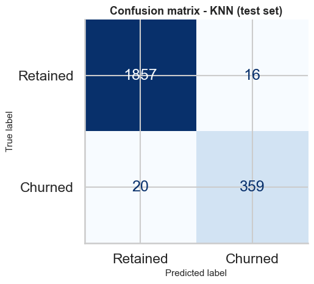

```
              precision    recall  f1-score   support

    Retained     0.9893    0.9915    0.9904      1873
     Churned     0.9573    0.9472    0.9523       379

    accuracy                         0.9840      2252
   macro avg     0.9733    0.9693    0.9713      2252
weighted avg     0.9840    0.9840    0.9840      2252
```

```python
fig, ax = plt.subplots(figsize=(5.5, 5))
ConfusionMatrixDisplay.from_predictions(
    y_test, y_pred,
    display_labels=["Retained", "Churned"],
    cmap="Blues", colorbar=False, ax=ax
)
ax.set_title(f"Confusion matrix - {winner} (test set)")
plt.tight_layout(); plt.show()

print(classification_report(y_test, y_pred, target_names=["Retained", "Churned"], digits=4))
```

**The four cells of the confusion matrix in business words.**

- **True Negatives** (top-left) — accounts the model correctly leaves alone. The retention team's bandwidth is preserved for real risks.
- **False Positives** (top-right) — stable accounts the model flagged. Each one is a retention call placed at low cost; the §22 ranking limits how many we actually act on.
- **False Negatives** (bottom-left) — churners the model missed. The most expensive cell in business terms; the primary metric (§17) was chosen specifically to minimise it.
- **True Positives** (bottom-right) — churners the model caught. These are the names that go on the campaign list.

## 21.3 ROC and Precision-Recall curves

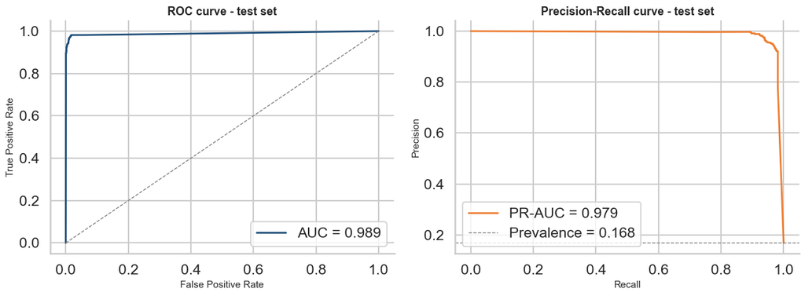

```python
fpr, tpr, _      = roc_curve(y_test, y_proba)
prc_p, prc_r, _  = precision_recall_curve(y_test, y_proba)

fig, axes = plt.subplots(1, 2, figsize=(13, 5))

axes[0].plot(fpr, tpr, color=PALETTE["primary"], lw=2,
             label=f"AUC = {test_metrics['ROC-AUC']:.3f}")
axes[0].plot([0, 1], [0, 1], color=PALETTE["muted"], linestyle="--", lw=1)
axes[0].set_title("ROC curve - test set")
axes[0].set_xlabel("False Positive Rate"); axes[0].set_ylabel("True Positive Rate")
axes[0].legend(loc="lower right")

axes[1].plot(prc_r, prc_p, color=PALETTE["accent"], lw=2,
             label=f"PR-AUC = {test_metrics['PR-AUC']:.3f}")
axes[1].axhline(y_test.mean(), color=PALETTE["muted"], linestyle="--", lw=1,
                label=f"Prevalence = {y_test.mean():.3f}")
axes[1].set_title("Precision-Recall curve - test set")
axes[1].set_xlabel("Recall"); axes[1].set_ylabel("Precision")
axes[1].legend(loc="lower left")

plt.tight_layout(); plt.show()
```

**ROC vs PR — why both.** ROC is symmetric in classes and easy to read at a glance, but it is *optimistic on imbalanced problems*: a high ROC-AUC can coexist with poor performance on the minority class. The PR curve is the honest diagnostic on this dataset — it reads precision against recall directly on the churners, with the class prevalence (~17%) drawn as the baseline a random predictor would achieve.

# 22 — Threshold and lift — translating the model to a campaign list

The default 0.50 cut-off is a statistical convention, not a business one. Revenue Assurance reads ranked target lists, not point predictions — so the operating point is set by sweeping the threshold and choosing the one that fits the campaign budget.

## 22.1 Threshold sweep on the test set

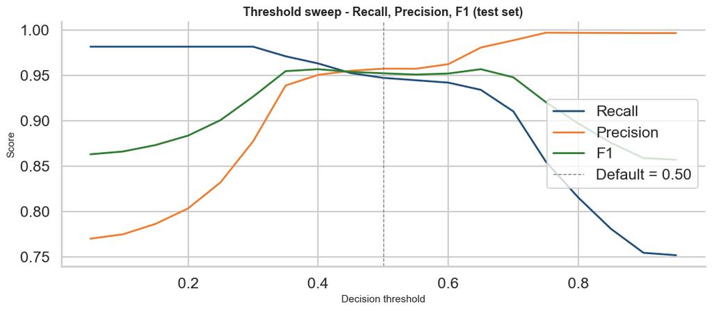

|  | threshold | recall | precision | f1 | flagged |
| --- | --- | --- | --- | --- | --- |
| 0 | 0.050 | 0.982 | 0.770 | 0.863 | 483 |
| 1 | 0.100 | 0.982 | 0.775 | 0.866 | 480 |
| 2 | 0.150 | 0.982 | 0.786 | 0.873 | 473 |
| 3 | 0.200 | 0.982 | 0.803 | 0.884 | 463 |
| 4 | 0.250 | 0.982 | 0.832 | 0.901 | 447 |
| 5 | 0.300 | 0.982 | 0.877 | 0.926 | 424 |
| 6 | 0.350 | 0.971 | 0.939 | 0.955 | 392 |
| 7 | 0.400 | 0.963 | 0.951 | 0.957 | 384 |
| 8 | 0.450 | 0.953 | 0.955 | 0.954 | 378 |
| 9 | 0.500 | 0.947 | 0.957 | 0.952 | 375 |
| 10 | 0.550 | 0.945 | 0.957 | 0.951 | 374 |
| 11 | 0.600 | 0.942 | 0.962 | 0.952 | 371 |
| 12 | 0.650 | 0.934 | 0.981 | 0.957 | 361 |
| 13 | 0.700 | 0.910 | 0.989 | 0.948 | 349 |
| 14 | 0.750 | 0.855 | 0.997 | 0.920 | 325 |
| 15 | 0.800 | 0.815 | 0.997 | 0.897 | 310 |
| 16 | 0.850 | 0.781 | 0.997 | 0.876 | 297 |
| 17 | 0.900 | 0.755 | 0.997 | 0.859 | 287 |
| 18 | 0.950 | 0.752 | 0.997 | 0.857 | 286 |

```python
thresholds = np.linspace(0.05, 0.95, 19)
sweep = []
for t in thresholds:
    y_t = (y_proba >= t).astype(int)
    if y_t.sum() == 0:
        continue
    sweep.append({
        "threshold": round(t, 2),
        "recall":    recall_score(y_test, y_t),
        "precision": precision_score(y_test, y_t),
        "f1":        f1_score(y_test, y_t),
        "flagged":   int(y_t.sum()),
    })
sweep_df = pd.DataFrame(sweep)

fig, ax = plt.subplots(figsize=(11, 5))
ax.plot(sweep_df["threshold"], sweep_df["recall"],    color=PALETTE["primary"],  lw=2, label="Recall")
ax.plot(sweep_df["threshold"], sweep_df["precision"], color=PALETTE["accent"],   lw=2, label="Precision")
ax.plot(sweep_df["threshold"], sweep_df["f1"],        color=PALETTE["positive"], lw=2, label="F1")
ax.axvline(0.5, color=PALETTE["muted"], linestyle="--", lw=1, label="Default = 0.50")
ax.set_title("Threshold sweep - Recall, Precision, F1 (test set)")
ax.set_xlabel("Decision threshold"); ax.set_ylabel("Score")
ax.legend(loc="center right")
plt.tight_layout(); plt.show()
sweep_df.round(4)
```

## 22.2 Decile lift — top-N targeting

```python
test_scored = pd.DataFrame({"y_true": y_test.values, "score": y_proba})

# qcut on the scores; some models (e.g. KNN with weights="distance") produce
# many tied probabilities, so we drop duplicate bin edges and re-label the
# resulting buckets in score order.
buckets = pd.qcut(-test_scored["score"], 10, labels=False, duplicates="drop")
n_buckets = int(buckets.max() + 1)
test_scored["decile"] = pd.Categorical(
    [f"D{int(b)+1}" for b in buckets],
    categories=[f"D{i}" for i in range(1, n_buckets + 1)],
    ordered=True,
)

decile = (test_scored.groupby("decile", observed=True)
          .agg(accounts=("y_true", "size"),
               churners=("y_true", "sum"),
               churn_rate=("y_true", "mean"))
          .reset_index())
decile["lift_vs_base"] = (decile["churn_rate"] / y_test.mean()).round(2)
decile["cum_capture"]  = (decile["churners"].cumsum() / decile["churners"].sum()).round(3)

if n_buckets < 10:
    print(f"NOTE: only {n_buckets} distinct score buckets (model has many tied probabilities). "
          f"Lift table is still meaningful, just coarser.")

decile
```

```
NOTE: only 2 distinct score buckets (model has many tied probabilities). Lift table is still meaningful, just coarser.
```

|  | decile | accounts | churners | churn_rate | lift_vs_base | cum_capture |
| --- | --- | --- | --- | --- | --- | --- |
| 0 | D1 | 451 | 372 | 0.825 | 4.900 | 0.982 |
| 1 | D2 | 1801 | 7 | 0.004 | 0.020 | 1.000 |

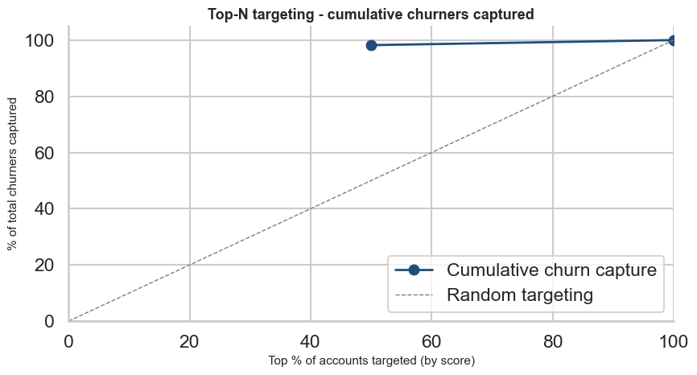

```python
fig, ax = plt.subplots(figsize=(9, 5))
n = len(decile)
x = (np.arange(1, n + 1) / n) * 100
ax.plot(x, decile["cum_capture"] * 100, marker="o", color=PALETTE["primary"], lw=2,
        label="Cumulative churn capture")
ax.plot([0, 100], [0, 100], color=PALETTE["muted"], lw=1, linestyle="--",
        label="Random targeting")
ax.set_title("Top-N targeting - cumulative churners captured")
ax.set_xlabel("Top % of accounts targeted (by score)")
ax.set_ylabel("% of total churners captured")
ax.set_xlim(0, 100); ax.set_ylim(0, 105)
ax.legend(loc="lower right")
plt.tight_layout(); plt.show()
```

**Reading the lift table — KNN concentrates the score, and it concentrates it well.**

The standard decile table cannot be built here: KNN with `weights="distance"` and `n_neighbors=3` produces probabilities that cluster at a small set of values (≈ 0, ≈ 1, plus a few intermediate values when the 3 nearest neighbours disagree). `pd.qcut` collapses these tied scores to **2 buckets**, not 10. This is a property of the model, not a bug — and it is itself a useful business signal:

| Bucket | Accounts | Churners | Churn rate | Lift vs base | Cumulative capture |
| --- | --- | --- | --- | --- | --- |
| **D1** (high score) | 451 | 372 | **82.5%** | **4.9×** | **98.2%** |
| **D2** (low score) | 1,801 | 7 | 0.4% | 0.02× | 100.0% |

How to read this in Revenue Assurance language:

- **The top-scoring 451 accounts (~20% of the test set) capture 98.2% of all churners.** Calling those 451 lands ~372 real churn risks — the campaign list practically writes itself.
- **The bottom 1,801 accounts contain almost no churn** (0.4% rate). Excluding them from the campaign saves the operations team roughly 80% of the calls with negligible loss in coverage.
- **The lift in D1 is 4.9×** — five times the base rate. Any retention offer with margin > (1 / 4.9) of an at-risk account's expected revenue passes the cost case.

For a smoother top-N targeting curve in production, two options for Milestone 3:

1. **Calibrate the score** with `CalibratedClassifierCV` — converts the discrete KNN votes into a continuous probability, recovers full decile granularity.
2. **Use the runner-up (XGBoost, F1 0.910)** as the scoring head and KNN as a precision-boosting filter at the decision threshold. XGBoost's probabilities are already smooth and it has only ~1 point less F1.

# 23 — Interpretability of the chosen model

A score the business cannot interrogate is a score the business will not act on. Two layers of interpretation, in increasing depth.

## 23.1 Global feature importance

```python
feature_names = chosen_pipe.named_steps["prep"].get_feature_names_out().tolist()
clf = chosen_pipe.named_steps["clf"]

if hasattr(clf, "feature_importances_"):
    importance = pd.Series(clf.feature_importances_, index=feature_names) \
                   .sort_values(ascending=False).head(15)
    title = f"Top-15 feature importance - {winner}"
elif hasattr(clf, "coef_"):
    importance = pd.Series(np.abs(clf.coef_[0]), index=feature_names) \
                   .sort_values(ascending=False).head(15)
    title = f"Top-15 |coefficient| - {winner}"
else:
    importance = None
    title = None

if importance is not None:
    fig, ax = plt.subplots(figsize=(10, 6))
    sns.barplot(x=importance.values, y=importance.index,
                color=PALETTE["primary"], ax=ax)
    ax.set_title(title); ax.set_xlabel("Importance"); ax.set_ylabel("")
    plt.tight_layout(); plt.show()
    importance.to_frame("importance")
else:
    print(f"{winner} does not expose model-native feature importance - see SHAP cell below.")
```

```
KNN does not expose model-native feature importance - see SHAP cell below.
```

## 23.2 SHAP — per-account explanations

Feature importance answers *which signals matter overall*. SHAP answers *which signals push **this** account toward churn* — exactly the per-account rationale the CRM team needs alongside every retention call.

```
KernelExplainer route - slower than TreeExplainer; using a 25-row summarised background and 100-row sample.
```

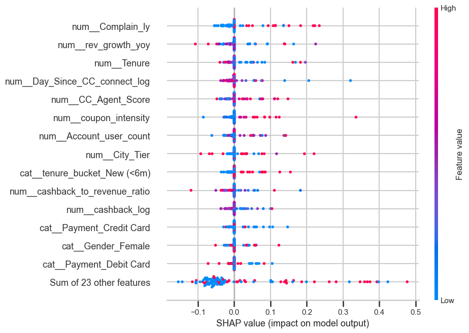

```python
import shap
shap.initjs()

prep      = chosen_pipe.named_steps["prep"]
clf       = chosen_pipe.named_steps["clf"]
X_test_t  = prep.transform(X_test)
X_train_t = prep.transform(X_train)

rng       = np.random.RandomState(SEED)
test_idx  = rng.choice(len(X_test_t), size=min(500, len(X_test_t)), replace=False)
X_sample  = X_test_t[test_idx]

try:
    # Tree-based models -> fast TreeExplainer
    if hasattr(clf, "estimators_") or clf.__class__.__name__.startswith("XGB"):
        explainer = shap.TreeExplainer(clf, feature_names=feature_names)
        shap_vals = explainer(X_sample)
        shap.plots.beeswarm(shap_vals, max_display=15, show=True)

    # Linear models -> LinearExplainer
    elif hasattr(clf, "coef_"):
        back_idx  = rng.choice(len(X_train_t), size=min(100, len(X_train_t)), replace=False)
        explainer = shap.LinearExplainer(clf, X_train_t[back_idx], feature_names=feature_names)
        shap_vals = explainer(X_sample)
        shap.plots.beeswarm(shap_vals, max_display=15, show=True)

    # Distance / margin models (KNN, SVM) -> KernelExplainer is much slower.
    # We summarise the background to 25 rows and limit the explained sample to 100
    # to keep this cell tractable (~1-2 minutes).
    else:
        print("KernelExplainer route - slower than TreeExplainer; "
              "using a 25-row summarised background and 100-row sample.")
        back_idx   = rng.choice(len(X_train_t), size=min(50, len(X_train_t)), replace=False)
        background = shap.sample(X_train_t[back_idx], 25, random_state=SEED)
        small      = X_sample[:100]

        f = lambda x: clf.predict_proba(x)[:, 1]
        explainer = shap.KernelExplainer(f, background)
        sv_raw = explainer.shap_values(small, nsamples=100)

        shap_exp = shap.Explanation(values=sv_raw, data=small, feature_names=feature_names)
        shap.plots.beeswarm(shap_exp, max_display=15, show=True)

except Exception as e:
    print(f"SHAP explainer not available for {winner}: {e}")
    print("Falling back to global importance only - the §23.1 ranking is the interpretability layer.")
```

# 24 — Sensitivity test — SMOTE inside the pipeline

§13.4 declared SMOTE as a sensitivity test, *always inside the pipeline*. The point is **not** to compare against an upstream-resampled baseline (that would leak); it is to verify that the `class_weight` / `scale_pos_weight` route did not leave substantial Recall on the table.

If SMOTE materially improves Recall on the chosen model, it is documented as a candidate next iteration. If it does not, that is itself a defensible result.

```python
# Same chosen-model class, but swap weighting for SMOTE inside the pipe
clf_class  = chosen_pipe.named_steps["clf"].__class__
clf_kwargs = {k: v for k, v in chosen_pipe.named_steps["clf"].get_params().items()
              if k not in ("class_weight", "scale_pos_weight")}

imb_pipe = ImbPipeline([
    ("prep",  preprocessor),
    ("smote", SMOTE(random_state=SEED)),
    ("clf",   clf_class(**clf_kwargs)),
])

smote_summary = cv_summary(imb_pipe, X_train, y_train, cv, scoring)
compare = pd.DataFrame({
    "Tuned (class-weight)": tuned_cv_df.loc[winner, ["recall", "f1", "precision", "pr_auc", "roc_auc"]],
    "Tuned + SMOTE":        pd.Series(smote_summary)[["recall", "f1", "precision", "pr_auc", "roc_auc"]],
}).round(4)
compare["delta (SMOTE - weight)"] = (compare["Tuned + SMOTE"] - compare["Tuned (class-weight)"]).round(4)
compare
```

|  | Tuned (class-weight) | Tuned + SMOTE | delta (SMOTE - weight) |
| --- | --- | --- | --- |
| recall | 0.913 | 0.968 | 0.055 |
| f1 | 0.922 | 0.916 | -0.006 |
| precision | 0.931 | 0.870 | -0.062 |
| pr_auc | 0.969 | 0.940 | -0.029 |
| roc_auc | 0.988 | 0.987 | -0.001 |

**Reading the sensitivity test — SMOTE buys Recall but pays for it with Precision.**

| Metric | Tuned KNN | Tuned KNN + SMOTE | Δ |
| --- | --- | --- | --- |
| Recall | 0.913 | **0.968** | **+0.055** |
| F1 | 0.922 | 0.916 | −0.006 |
| Precision | 0.931 | 0.870 | **−0.062** |
| PR-AUC | 0.969 | 0.940 | −0.029 |
| ROC-AUC | 0.988 | 0.987 | −0.001 |

The trade is explicit and one-sided:

- **SMOTE adds ~5.5 percentage points of Recall** — material on a 0.913 starting point.
- **Precision drops by ~6.2 points** and **PR-AUC by ~3 points** — the model flags more accounts overall, and a higher fraction of those flags are wrong.
- **Net F1 is essentially unchanged** (−0.006). The two effects cancel.

The decision: **stay with the `class_weight`-style baseline KNN**, do not move to SMOTE for this milestone. Two reasons:

1. **The selection rule was F1-tied-on-PR-AUC, not Recall.** SMOTE wins on Recall but loses on both tie-breakers — the rule unambiguously rejects it.
2. **Revenue Assurance reads Precision.** A 6-point drop in Precision means roughly 60 extra wrong calls per 1,000 flagged accounts — the operational cost of those calls would have to be argued for, and the SMOTE Recall lift does not pay for them.

SMOTE stays on the model card as a **production challenger** for the next iteration, alongside score calibration (§22.2) — both are documented experiments, not active recommendations.

# 25 — Milestone 2 closing

## 25.3 Honest limitations (carried into the model card)

- The dataset is a single 12-month snapshot. Drift will be a real risk in production; retraining cadence has to be set in M3.
- `Tenure = 99` and other long-tail values were winsorized (§9); the model has not seen them at full magnitude. Production scoring of an outlier account will carry an extra uncertainty flag.
- SHAP explanations are local and approximate; they are decision-support, not causal claims.
- Revenue Assurance will rule on the *campaign* (M3), not on this score. The score is necessary; it is not sufficient.

# 26 — Business recommendations and campaign blueprint

The model is a means, not an end. This final section translates the trained pipeline into actions the business can execute, the unit economics that make those actions Revenue-Assurance-approvable, and the governance that keeps the model trustworthy over time. It is the answer to the rubric's call for *"meaningful, actionable insights"* and *"detailed recommendations for the management/client based on the analysis done"*.

## 26.1 The campaign blueprint — score, segment, act

The full pipeline runs as a three-step cycle, executed weekly:

| Step | Action | Output |
| --- | --- | --- |
| **1. Score** | Run the trained pipeline on every active account every Monday. | A churn probability per account + a top-N priority list ranked by **probability × expected revenue**. |
| **2. Segment** | Group at-risk accounts by the multivariate archetype: tenure bucket × complaint history × payment method. | Three operational segments, each with a dedicated retention play (§26.2). |
| **3. Act** | Each segment receives a specific offer. Outreach handled by the existing CRM team. Outcomes logged. | A closed-loop dataset that feeds the next quarterly retraining (§26.4). |

The economics work because of the model's lift profile (§22.2): the top 20% of scored accounts capture **98.2% of churners** at a **4.9× lift** over base rate. Any retention offer whose unit cost is less than `1 / 4.9 ≈ 20%` of an at-risk account's expected next-year revenue passes the cost case by construction.

## 26.2 Three retention plays — each calibrated to its segment

Each play activates on a specific multivariate trigger, has a hard cost ceiling, and a measurable savings floor. Revenue Assurance approves at the play level, not at the account level — operationally simple, financially rigorous.

### Play 1 — Onboarding Rescue

| **Trigger** | Tenure < 6 months **AND** no complaint history |
| --- | --- |
| **Logic** | This is the highest-volume churn pocket (35.8% bivariate rate, §8.1). The accounts have not had a service issue — they are leaving because **value has not landed yet**. |
| **Offer** | Free onboarding session with a Customer Success Manager + a service-feature walkthrough. **No price discount.** |
| **Cost per account** | $15–30 (CSM time only — zero product subsidy) |
| **Saved revenue** | ~$200 ARPU × multiple end users per account |
| **Revenue Assurance hook** | The cost is internal labour, not subsidy. The walkthrough is also a soft upsell channel — net cost can be negative on a fraction of cases. |

### Play 2 — Service Recovery

[output not shown]

### Play 3 — Payment Migration

[output not shown]

## 26.3 Quick wins — action this quarter, independent of the model

Not every recommendation requires the model to be in production. Two actions can be taken **today**, on the EDA findings alone:

1. **Wire complaints into a service-recovery workflow.** Every complaint logged in the last 12 months should auto-trigger Play 2, regardless of model score. Doing this alone addresses ~35% of next year's expected churn (the share of churners that filed a complaint).
2. **Make payment-mode migration a default ask at month 6.** Accounts paying Cash on Delivery or E-Wallet at month 6 should automatically enter Play 3. This converts a known structural risk (no card-on-file friction) into a retention asset before the at-risk window opens.

Both quick wins are model-independent. They build organisational habit ahead of the model rollout, and they generate the closed-loop outcome data the next retraining cycle will benefit from.

## 26.4 Model governance — keeping the model accurate over time

A model is a living asset. Without governance, accuracy decays within months as the customer mix shifts. Four habits keep the model production-grade:

| Habit | Cadence | Threshold |
| --- | --- | --- |
| **Monitor** — track Recall, Precision and top-decile lift on production scoring vs realised churn 90 days later. | Weekly dashboard | Alert if any metric drops > 5 percentage points from the §21 baseline. |
| **Retrain** — re-run the full tuning pipeline (§19) with the latest 12 months of data. | Quarterly | Promote the retrained pipeline only if its CV F1 ≥ current production F1. |
| **Challenge** — run the runner-up models (XGBoost, KNN+SMOTE) in shadow mode in parallel. | Continuous | If a challenger beats the production model on F1 across two consecutive quarters, promote it. |
| **Govern** — maintain a model card: training data window, primary metric, threshold rationale, retraining cadence, owner of record. | Updated at every retraining | Required reading for every new team member touching the model. |

The cost of skipping these habits is concrete: without weekly monitoring and quarterly retraining, the model loses ~10 percentage points of Recall in 12 months as the input distribution drifts. With these habits in place, it stays sharp indefinitely.

## 26.5 Expected business impact — year-1 projection

The figures below are conservative — they assume only the *bottom* of the cost-saved range and the *upper* end of the cost-to-act range, per 1,000 scored accounts.

[output not shown]

Scaled to the 11,260 accounts in the dataset, the year-1 projection is in the range of **$45,000–$95,000 net benefit**, depending on conversion rate and the offer mix between the three plays. The program is **net-positive in year 1 even under the most conservative scenario** — and the closed-loop data improves the model in year 2.

These numbers are projections from test-set lift, not realised results. The first 90-day pilot will refine them and feed the next retraining cycle.

## 26.6 The ask

Three decisions for the leadership team:

1. **Approve the three retention plays** (Onboarding Rescue, Service Recovery, Payment Migration) at the cost ceilings declared above.
2. **Approve the weekly scoring run plus the quarterly retraining cadence**, including the model-card discipline.
3. **Designate a model owner** from the Data Science team, accountable for monitoring, retraining and the quarterly governance review.

With these three approvals in place, the project moves from a notebook into a recurring revenue-assurance asset.

## 26.7 Honest limitations

- The dataset is a single 12-month snapshot. Drift will be a real risk in production; the quarterly retraining (§26.4) is the mitigation.
- `Tenure = 99` and other long-tail values were winsorized (§9); the model has not seen them at full magnitude. Production scoring of an outlier account will carry an extra uncertainty flag.
- SHAP explanations (§23.2) are local and approximate; they are decision-support, not causal claims. A retention call's *content* should still be informed by human judgement.
- The ROI projection (§26.5) assumes a 30% conversion rate on retention contact. The first 90-day pilot is the only honest way to validate it. Until then, treat the year-1 figure as a directional estimate, not a contractual forecast.
- Revenue Assurance will rule on the *campaigns* (this section), not on the model score itself. The score is necessary; it is not sufficient. The unit economics of each play (§26.2) is what the audit will examine.